# SNA SOBRE CASO ENRON

Laura Llorente Martínez

2024-05-02 para la asignatura BAIN-2024 @U-TAD

[figure not shown]

Portada Caso ENRON

# Instalación y Carga de Paquetes Necesarios, Directorio de Trabajo

Cargamos librerías necesarias y establecemos el directorio de trabajo:

```r
library(igraph)      # Para el manejo de grafos
library(tidyverse)   # Para manipulación de datos
library(tidytext)    # Para el análisis de texto
library(dplyr)       # Para manipulación de datos
library(ggplot2)     # Para visualización de datos

# Directorio de trabajo
setwd("D:/Laura - UTAD/Tercero/Segundo cuatrimestre/Búsqueda y Análisis de la Información/Tareas/Tarea 2")
```

# Lectura de datasets de nodos y enlaces y carga de datos para la preparación del grafo ENRON

Cargamos los datos necesarios para el estudio del caso Enron:

El caso Enron se refiere al colapso y escándalo financiero de Enron Corporation, una empresa estadounidense de energía que tenía su sede en Houston (Texas). Este escándalo salió a la luz en octubre de 2001 y es uno de los más grandes y notorios casos de fraude y corrupción corporativa en la historia.

```r
# Cargamos el archivo enron.RData
load("./SNA_talleR_muRcia-main/enron.RData")

# Cargamos el archivo edges_w_message.RData
load("./SNA_talleR_muRcia-main/edges_w_message/edges_w_message.RData")
```

Exploramos la estructura de los datos cargados para entender mejor lo que contienen:

```r
# Mostrar la estructura del dataframe de enlaces para revisar las columnas y tipos de datos
str(edges)
```

```
## 'data.frame':    4308 obs. of  5 variables:
##  $ sender  : Factor w/ 144 levels "albert.meyers@enron.com",..: 1 1 1 1 2 2 2 2 2 2 ...
##  $ reciever: Factor w/ 146 levels "albert.meyers@enron.com",..: 7 7 7 120 8 13 39 65 108 113 ...
##  $ type    : Factor w/ 3 levels "BCC","CC","TO": 3 2 1 3 3 3 3 3 3 3 ...
##  $ date    : Date, format: "2002-01-29" "2002-01-25" ...
##  $ count   : num  3 1 1 2 1 1 1 1 1 22 ...
```

```r
# Corregimos el nombre de la columna 'receiver' que estaba mal escrito
names(edges)[2] <- "receiver"
str(edges)
```

```
## 'data.frame':    4308 obs. of  5 variables:
##  $ sender  : Factor w/ 144 levels "albert.meyers@enron.com",..: 1 1 1 1 2 2 2 2 2 2 ...
##  $ receiver: Factor w/ 146 levels "albert.meyers@enron.com",..: 7 7 7 120 8 13 39 65 108 113 ...
##  $ type    : Factor w/ 3 levels "BCC","CC","TO": 3 2 1 3 3 3 3 3 3 3 ...
##  $ date    : Date, format: "2002-01-29" "2002-01-25" ...
##  $ count   : num  3 1 1 2 1 1 1 1 1 22 ...
```

```r
# Exploramos la estructura de los demás dataframes cargados
str(edges.full)
```

```
## 'data.frame':    61673 obs. of  6 variables:
##  $ sender  : chr  "mary.hain@enron.com" "mary.hain@enron.com" "mary.hain@enron.com" "cooper.richey@enron.com" ...
##  $ receiver: chr  "sean.crandall@enron.com" "mike.swerzbin@enron.com" "robert.badeer@enron.com" "robert.badeer@enron.com" ...
##  $ type    : chr  "TO" "TO" "TO" "TO" ...
##  $ subject : chr  "Enron s transmission/power exchange model for discussion" "Enron s transmission/power exchange model for discussion" "Enron s transmission/power exchange model for discussion" "Change to EnData" ...
##  $ body    : chr  "---------------------- Forwarded by Mary Hain/HOU/ECT on 08/17/2000 02:15 PM ---------------------------James D"| __truncated__ "---------------------- Forwarded by Mary Hain/HOU/ECT on 08/17/2000 02:15 PM ---------------------------James D"| __truncated__ "--------------------…
##  $ date    : chr  "2000-08-17 07:11:00" "2000-08-17 07:11:00" "2000-08-17 07:11:00" "2000-08-23 04:39:00" ...
```

```r
str(nodes)
```

```
## 'data.frame':    149 obs. of  3 variables:
##  $ Email_id: chr  "marie.heard@enron.com" "mark.e.taylor@enron.com" "lindy.donoho@enron.com" "lisa.gang@enron.com" ...
##  $ lastName: chr  "Heard" "Taylor" "Donoho" "Gang" ...
##  $ status  : chr  "N/A" "Employee" "Employee" "N/A" ...
```

```r
# Mostramos los nombres de las columnas del dataframe 'nodes' para entender la estructura de los datos
names(nodes)
```

```
## [1] "Email_id" "lastName" "status"
```

```r
# Contamos el número de enlaces
nrow(edges.full)
```

```
## [1] 61673
```

```r
# Convertimos la columna 'date' del dataframe 'edges.full' a formato POSIXct para facilitar la manipulación y análisis de fechas
edges.full$date.R <- as.POSIXct(edges.full$date)

# Generamos un resumen de las fechas convertidas
summary(edges.full$date.R)
```

```
##                       Min.                    1st Qu.
## "1998-11-13 04:07:00.0000" "2000-12-12 07:45:00.0000"
##                     Median                       Mean
## "2001-06-11 17:17:00.0000" "2001-05-08 21:44:27.9777"
##                    3rd Qu.                       Max.
## "2001-10-28 14:41:38.0000" "2002-06-21 13:37:34.0000"
```

# Creación del grafo

Agregamos información sobre los roles de los empleados desde un archivo externo y ajustamos los nombres de las columnas:

```r
# Leemos el archivo de roles
roles <- read.table("./SNA_talleR_muRcia-main/roles.txt", sep = "|", header = FALSE, fill = TRUE)

# Mostramos las primeras filas del dataframe 'roles' para obtener una vista preliminar de los datos
head(roles)
```

```
##              V1               V2             V3                V4
## 1 albert.meyers    Albert Meyers       Employee        Specialist
## 2     a..martin    Thomas Martin Vice President
## 3   andrea.ring      Andrea Ring            N/A
## 4  andrew.lewis     Andrew Lewis       Director
## 5   andy.zipper      Andy Zipper Vice President      Enron Online
## 6   a..shankman Jeffrey Shankman      President Enron Global Mkts
```

```r
# Establecemos los nombres de las columnas
names(roles) <- c("email_id_sin_arroba", "nombre_completo", "status", "role")

# Eliminamos el dominio '@enron.com' de los ID de email en el dataframe de nodos
nodes$email_id_sin_arroba <- gsub("@enron.com", "", nodes$Email_id)
```

```r
# Fusionamos los dataframes de nodos y roles para enriquecer la información de los nodos
nodes_rich <- merge(nodes, roles, by = "email_id_sin_arroba", all.x = TRUE, all.y = FALSE)

# Mostramos la estructura del dataframe 'nodes_rich'
str(nodes_rich)
```

```
## 'data.frame':    149 obs. of  7 variables:
##  $ email_id_sin_arroba: chr  "albert.meyers" "andrea.ring" "andy.zipper" "barry.tycholiz" ...
##  $ Email_id           : chr  "albert.meyers@enron.com" "andrea.ring@enron.com" "andy.zipper@enron.com" "barry.tycholiz@enron.com" ...
##  $ lastName           : chr  "Meyers" "Ring" "Zipper" "Tycholiz" ...
##  $ status.x           : chr  "Employee" "N/A" "Vice President" "Vice President" ...
##  $ nombre_completo    : chr  "Albert Meyers" "Andrea Ring" "Andy Zipper" "Barry Tycholiz" ...
##  $ status.y           : chr  "Employee" "N/A" "Vice President" "Vice President" ...
##  $ role               : chr  "Specialist" "" "Enron Online" "" ...
```

```r
# Abrimos una ventana de visualización interactiva para el dataframe 'nodes_rich'
View(nodes_rich)

# Creamos una tabla de contingencia para comparar las columnas 'status.x' y 'status.y' en 'nodes_rich'
table(nodes_rich$status.x, nodes_rich$status.y)
```

```
##
##                        CEO Director Employee In House Lawyer Manager
##   CEO                0   2        0        0               0       0
##   Director           0   0       11        0               0       0
##   Employee           1   0        0       31               0       0
##   In House Lawyer    0   0        0        0               1       0
##   Manager            1   0        0        0               0      10
##   Managing Director  0   0        0        0               0       0
##   N/A                8   0        0        0               0       0
##   President          0   0        0        0               0       0
##   Trader             1   0        0        0               0       0
##   Vice President     1   0        0        0               0       0
##
##                     Managing Director Managing Director  Legal Department N/A
##   CEO                               0                                   0   0
##   Director                          0                                   0   1
##   Employee                          0                                   0   3
##   In House Lawyer                   0                                   0   0
##   Manager                           0                                   0   0
##   Managing Director                 1                                   1   0
##   N/A                               0                                   0  15
##   President                         0                                   0   0
##   Trader                            0                                   0   0
##   Vice President                    0                                   0   0
##
##                     President Trader Vice President
##   CEO                       0      0              0
##   Director                  0      0              0
##   Employee                  0      0              0
##   In House Lawyer           0      0              0
##   Manager                   0      0              1
##   Managing Director         0      0              0
##   N/A                       0      0              0
##   President                 3      0              0
##   Trader                    0     11              0
##   Vice President            0      0             13
```

Creamos un grafo dirigido usando los datos de nodos y enlaces:

```r
# Reordenamiento de columnas en 'nodes_rich'
    # 2 indica que la segunda columna del dataframe original se moverá a la primera posición
    # 1 significa que la primera columna del dataframe original se moverá a la segunda posición
    # 3:length(names(nodes_rich)) conserva todas las demás columnas en su orden original a partir de la tercera posición
nodes_rich <- nodes_rich[,
                         c(2,
                           1,
                           3:length(names(nodes_rich)))]

# Volvemos a crear el grafo después de estos cambios
network.full <- graph.data.frame(edges.full[,c("sender",
                                               "receiver",
                                               "type",
                                               "date",
                                               "subject")],
                                 directed = TRUE,
                                 vertices = nodes_rich)
```

Propiedades del grafo que hemos creado:

```r
# Clase del objeto de grafo
class(network.full)
```

```
## [1] "igraph"
```

```r
# Resumen de las propiedades del grafo
summary(network.full)
```

```
## IGRAPH 53e7809 DN-- 149 61673 --
## + attr: name (v/c), email_id_sin_arroba (v/c), lastName (v/c), status.x
## | (v/c), nombre_completo (v/c), status.y (v/c), role (v/c), type (e/c),
## | date (e/c), subject (e/c)
```

```r
# Accedemos a los primeros 10 nodos del grafo 'network.full' para inspeccionar sus atributos y etiquetas
V(network.full)[1:10]
```

```
## + 10/149 vertices, named, from 53e7809:
##  [1] albert.meyers@enron.com   andrea.ring@enron.com
##  [3] andy.zipper@enron.com     barry.tycholiz@enron.com
##  [5] benjamin.rogers@enron.com bill.rapp@enron.com
##  [7] bill.williams@enron.com   brad.mckay@enron.com
##  [9] c..giron@enron.com        cara.semperger@enron.com
```

```r
# Accedemos a las primeras 10 aristas del grafo 'network.full' para ver cómo están conectados los nodos
E(network.full)[1:10]
```

```
## + 10/61673 edges from 53e7809 (vertex names):
##  [1] mary.hain@enron.com    ->sean.crandall@enron.com
##  [2] mary.hain@enron.com    ->mike.swerzbin@enron.com
##  [3] mary.hain@enron.com    ->robert.badeer@enron.com
##  [4] cooper.richey@enron.com->robert.badeer@enron.com
##  [5] mary.hain@enron.com    ->m..forney@enron.com
##  [6] mary.hain@enron.com    ->robert.badeer@enron.com
##  [7] mary.hain@enron.com    ->mike.swerzbin@enron.com
##  [8] jeff.dasovich@enron.com->james.d.steffes@enron.com
##  [9] jeff.dasovich@enron.com->richard.shapiro@enron.com
## [10] jeff.dasovich@enron.com->james.d.steffes@enron.com
```

```r
# Creamos una tabla de contingencia para analizar la distribución de la variable 'status.x' entre los nodos del grafo: cuántos nodos hay en cada estado específico dentro del grafo
table(V(network.full)$status.x)
```

```
##
##               CEO          Director          Employee   In House Lawyer
##                 4                14                41                 1
##           Manager Managing Director               N/A         President
##                14                 3                32                 4
##            Trader    Vice President
##                13                23
```

```r
# Creamos una tabla de contingencia para analizar la distribución de la variable 'role' entre los nodos del grafo: cuántos nodos desempeñan cada rol específico dentro del grafo
table(V(network.full)$role)
```

```
##
##
##                                         92
##                   Administrative Asisstant
##                                          1
## Also Chief Financial Officer and Treasurer
##                                          1
##                                    Analyst
##                                          1
##                    Analyst Risk Management
##                                          1
##                                  Associate
##                                          1
##                               Cash Analyst
##                                          1
##                    Chief Operating Officer
##                                          1
##              Chief Risk Management Officer
##                                          1
##       Enery marketting and trading Florida
##                                          1
##                         Enron Gas Pipeline
##                                          1
##                               Enron Online
##                                          2
##              Government Relation Executive
##                                          1
##                          Pipeline Business
##                                          1
##                     Real time Trading Desk
##                                          1
##                         Regulatory Affairs
##                                          3
##                       Risk Management Head
##                                          1
##                        Senior Analyst Cash
##                                          1
##                Senior Specialist Logistics
##                                          1
##                                 Specialist
##                                          1
##                              Sr.Specialist
##                                          1
##                                       Term
##                                          1
```

Exportamos el grafo en formato GraphML para su posterior uso como con Gephi:

```r
write.graph(network.full, file = "network_enron_fechas.graphml", format = "graphml")

# Guardamos el directorio de trabajo
save.image("00_grafo_base.rda")
```

Dividimos los datos de correos electrónicos en subgrafos basados en intervalos de tiempo, para analizar la evolución de las interacciones de correo electrónico a lo largo del tiempo:

```r
# Definimos los intervalos de tiempo como listas de fechas de inicio y fin
timeframes <- list(c("2001-01-01", "2001-07-01"), c("2001-07-02", "2001-12-31"))

# Creamos subgrafos para cada intervalo de tiempo
subgraphs <- lapply(timeframes, function(dates) {
  start_date <- as.Date(dates[1])
  end_date <- as.Date(dates[2])

  # Obtenemos los índices de las aristas en el rango de fechas
  edge_ids <- which(E(network.full)$date >= start_date & E(network.full)$date <= end_date)

  # Obtenemos los vértices asociados con estas aristas
  vertex_ids <- unique(c(ends(network.full, edge_ids)))

  # Creamos el subgrafo con los vértices asociados
  subgraph <- induced_subgraph(network.full, vids = vertex_ids)

  return(subgraph)
})

# Inspeccionamos los subgrafos
lapply(subgraphs, summary)
```

```
## IGRAPH 5634261 DN-- 143 61045 --
## + attr: name (v/c), email_id_sin_arroba (v/c), lastName (v/c), status.x
## | (v/c), nombre_completo (v/c), status.y (v/c), role (v/c), type (e/c),
## | date (e/c), subject (e/c)
## IGRAPH 56d549b DN-- 142 56030 --
## + attr: name (v/c), email_id_sin_arroba (v/c), lastName (v/c), status.x
## | (v/c), nombre_completo (v/c), status.y (v/c), role (v/c), type (e/c),
## | date (e/c), subject (e/c)
```

```
## [[1]]
## IGRAPH 5634261 DN-- 143 61045 --
## + attr: name (v/c), email_id_sin_arroba (v/c), lastName (v/c), status.x
## | (v/c), nombre_completo (v/c), status.y (v/c), role (v/c), type (e/c),
## | date (e/c), subject (e/c)
## + edges from 5634261 (vertex names):
## [1] mary.hain@enron.com    ->sean.crandall@enron.com
## [2] mary.hain@enron.com    ->mike.swerzbin@enron.com
## [3] mary.hain@enron.com    ->robert.badeer@enron.com
## [4] cooper.richey@enron.com->robert.badeer@enron.com
## [5] mary.hain@enron.com    ->m..forney@enron.com
## [6] mary.hain@enron.com    ->robert.badeer@enron.com
## + ... omitted several edges
##
## [[2]]
## IGRAPH 56d549b DN-- 142 56030 --
## + attr: name (v/c), email_id_sin_arroba (v/c), lastName (v/c), status.x
## | (v/c), nombre_completo (v/c), status.y (v/c), role (v/c), type (e/c),
## | date (e/c), subject (e/c)
## + edges from 56d549b (vertex names):
## [1] cooper.richey@enron.com->robert.badeer@enron.com
## [2] jeff.dasovich@enron.com->james.d.steffes@enron.com
## [3] jeff.dasovich@enron.com->richard.shapiro@enron.com
## [4] jeff.dasovich@enron.com->james.d.steffes@enron.com
## [5] jeff.dasovich@enron.com->richard.shapiro@enron.com
## [6] jeff.dasovich@enron.com->james.d.steffes@enron.com
## + ... omitted several edges
```

Las fechas “2001-01-01” y “2001-07-01” marcan el inicio y el final del primer semestre del año 2001, respectivamente. Las fechas “2001-07-02” y “2001-12-31” representan el segundo semestre del año 2001. Estas fechas son importantes en el caso Enron debido a que en ese período de tiempo se produjeron una serie de eventos significativos relacionados con el escándalo de Enron:

- Enron enfrentó una creciente presión financiera y regulatoria.
- Se descubrieron irregularidades contables y financieras significativas en las operaciones de Enron.
- El 2 de diciembre de 2001, Enron se declaró en bancarrota, lo que marcó un hito importante en el escándalo corporativo y financiero más grande en la historia de Estados Unidos hasta ese momento.

# Métricas globales del grafo

## Diámetro

El diámetro de una red es la mayor distancia geodésica (longitud del camino más corto entre dos nodos) en la red. En igraph, `diameter()` devuelve la distancia, mientras que `get_diameter()` devuelve los nodos a lo largo del primer camino encontrado de esa distancia.

```r
# Los pesos de las aristas se usan por defecto, a menos que se establezcan en NA
diameter(network.full,
         weights=NA)
```

```
## [1] 5
```

```r
diameter(network.full,
         directed=FALSE)
```

```
## [1] 4
```

```r
# `get_diameter()` devuelve una secuencia de vértices
diam <- get_diameter(network.full, directed=TRUE)
diam
```

```
## + 6/149 vertices, named, from 53e7809:
## [1] albert.meyers@enron.com    bill.williams@enron.com
## [3] cara.semperger@enron.com   m..forney@enron.com
## [5] don.baughman@enron.com     joe.stepenovitch@enron.com
```

```r
# Devolvemos la clase del objeto 'diam' para confirmar que es una secuencia de vértices de igraph
class(diam)
```

```
## [1] "igraph.vs"
```

```r
# Convertimos la secuencia de vértices 'diam' a un vector de índices numéricos
as.vector(diam)
```

```
## [1]  1  7 10 87 26 60
```

```r
# Devolvemos los vértices más lejanos entre sí en el grafo
farthest_vertices(network.full)
```

```
## $vertices
## + 2/149 vertices, named, from 53e7809:
## [1] albert.meyers@enron.com    joe.stepenovitch@enron.com
##
## $distance
## [1] 5
```

## Densidad

La proporción de aristas presentes de todas las posibles aristas en la red.

```r
# Calculamos la densidad del grafo 'network.full', excluyendo los bucles (loops) en el cálculo
edge_density(network.full, loops=FALSE)
```

```
## [1] 2.796708
```

```r
# Calculamos la densidad de la red dirigida 'network.full' de manera manual, excluyendo bucles y considerando la dirección de las aristas
ecount(network.full)/(vcount(network.full)*(vcount(network.full)-1))
```

```
## [1] 2.796708
```

## Reciprocidad

La proporción de lazos reciprocados (para una red dirigida).

```r
# Calculamos y devolvemos la reciprocidad en el grafo, que es la proporción de aristas que son bidireccionales
reciprocity(network.full)
```

```
## [1] 0.4291992
```

```r
# Realizamos un censo de díadas y clasificamos las relaciones entre nodos en mutuas, asimétricas y nulas
dyad_census(network.full)
```

```
## $mut
## [1] 761
##
## $asym
## [1] 968
##
## $null
## [1] 9297
```

```r
# Sumamos el total de díadas mutuas, asimétricas y nulas para obtener el total de pares de nodos en el grafo
sum_dyads <-
  dyad_census(network.full)$mut +
  dyad_census(network.full)$asym +
  dyad_census(network.full)$null

# Calculamos la proporción de lazos reciprocados respecto al total de lazos dirigidos
reciprocity(network.full, mode = "ratio")
```

```
## [1] 0.2732359
```

## Transitividad

global - relación de triángulos (dirección ignorada) a tríos conectados.

local - relación de triángulos a tríos conectados de los cuales cada vértice es parte.

```r
# Calculamos la transitividad global de la red, tratando la red como no dirigida
transitivity(network.full, type="global")
```

```
## [1] 0.4212257
```

```r
# Calculamos la transitividad global de la red después de convertir la red dirigida en una red no dirigida, colapsando las aristas bidireccionales en una sola
transitivity(as.undirected(network.full, mode="collapse"))
```

```
## [1] 0.4212257
```

```r
# Calculamos la transitividad local para cada nodo y devolvemos el promedio de estos valores para toda la red
transitivity(network.full, type="local")
```

```
##       albert.meyers@enron.com         andrea.ring@enron.com
##                     0.8333333                     0.4632353
##         andy.zipper@enron.com      barry.tycholiz@enron.com
##                     0.5111111                     0.4102564
##     benjamin.rogers@enron.com           bill.rapp@enron.com
##                     0.5333333                     0.7333333
##       bill.williams@enron.com          brad.mckay@enron.com
##                     0.3238095                     0.5108225
##            c..giron@enron.com      cara.semperger@enron.com
##                           NaN                     0.4852941
##         carol.clair@enron.com      charles.weldon@enron.com
##                     0.8571429                     0.3508772
##       chris.dorland@enron.com       chris.germany@enron.com
##                     0.4444444                     0.2666667
##       chris.stokley@enron.com       cooper.richey@enron.com
##                     0.5090909                     0.4615385
##          craig.dean@enron.com            dan.hyvl@enron.com
##                     0.6785714                     0.3766234
##          dana.davis@enron.com       danny.mccarty@enron.com
##                     0.5166667                     0.5541126
##      daren.j.farmer@enron.com darrell.schoolcraft@enron.com
##                     0.3142857                     0.8095238
##    david.w.delainey@enron.com   debra.perlingiere@enron.com
##                     0.4634146                     0.3874644
##      diana.scholtes@enron.com        don.baughman@enron.com
##                     0.4632353                     0.5555556
##  doug.gilbert-smith@enron.com         drew.fossum@enron.com
##                     0.5523810                     0.4322581
##       dutch.quigley@enron.com         e..haedicke@enron.com
##                     0.4238095                     0.4849850
##     elizabeth.sager@enron.com           eric.bass@enron.com
##                     0.4475806                     0.4502165
##         eric.linder@enron.com          eric.saibi@enron.com
##                     1.0000000                     0.6944444
##    errol.mclaughlin@enron.com    fletcher.j.sturm@enron.com
##                     0.5619048                     0.4353659
##         frank.ermis@enron.com        geir.solberg@enron.com
##                     0.7134503                     0.6000000
##        geoff.storey@enron.com        gerald.nemec@enron.com
##                     0.4123077                     0.3484848
```

[output cut: 95 more lines]

```
##                     0.7105263                     0.5786290
##       steven.merris@enron.com      steven.p.south@enron.com
##                     1.0000000                     0.6684211
##        susan.bailey@enron.com         susan.scott@enron.com
##                     0.8000000                     0.2115722
##     susan.w.pereira@enron.com          tana.jones@enron.com
##                     0.6666667                     0.4047619
##           teb.lokey@enron.com       theresa.staab@enron.com
##                     0.7058824                     0.7111111
##     thomas.a.martin@enron.com         tom.donohoe@enron.com
##                     0.5543478                     0.5555556
##     tori.kuykendall@enron.com      tracy.geaccone@enron.com
##                     0.4655172                     0.8250000
##       vladi.pimenov@enron.com
##                     0.5666667
```

```r
# Realizamos un censo de tríadas en la red dirigida para clasificar todas las configuraciones posibles de tríadas según la dirección de las conexiones
triad_census(network.full)
```

```
##  [1] 331347  22811 148269   7578   2000   2977   4813   8421   1210     37
## [11]   4669    987    903    538   2276   1438
```

# Métricas individuales SNA del grafo

Usamos igraph para obtener los caminos más cortos entre dos nodos específicos:

```r
# Encontramos el camino más corto entre Albert Meyers y Thomas Martin
# Thomas Martin --> Vicepresidente
# Albert Meyers --> especialista
get.shortest.paths(from = V(network.full)$lastName == "Meyers",
                   to = V(network.full)$lastName == "Martin",
                   graph = network.full)
```

```
## $vpath
## $vpath[[1]]
## + 5/149 vertices, named, from 53e7809:
## [1] albert.meyers@enron.com    bill.williams@enron.com
## [3] kay.mann@enron.com         david.w.delainey@enron.com
## [5] thomas.a.martin@enron.com
##
##
## $epath
## NULL
##
## $predecessors
## NULL
##
## $inbound_edges
## NULL
```

```r
# Encontramos los índices de los vértices
meyers_index <- which(V(network.full)$lastName == "Meyers")
martin_index <- which(V(network.full)$lastName == "Martin")

# Mostramos información de los nodos para Meyers y Martin
nodes[c(meyers_index, martin_index),]
```

```
##                  Email_id lastName   status email_id_sin_arroba
## 1   marie.heard@enron.com    Heard      N/A         marie.heard
## 145 tom.donohoe@enron.com  Donohoe Employee         tom.donohoe
```

## Medidas de centralidad (Centrality measures)

Las medidas de centralidad son métricas utilizadas en el análisis de redes para determinar la importancia o el prestigio de los nodos dentro de una red. Estas medidas ayudan a identificar los nodos más influyentes, los puntos críticos de comunicación, o los intermediarios clave en la red.

### Centralidad de Grado (Degree)

Mide cuántas conexiones (aristas) tiene un nodo.

```r
# Asignamos el dataframe nodes_rich al dataframe original nodes para usarlo después
nodes <- nodes_rich

# Calculamos el grado total de cada nodo en el grafo
# El grado total representa el número total de conexiones (entrantes y salientes) para cada nodo
nodes$degree_total <- degree(network.full,
                             v = V(network.full),
                             mode = "total")

# Calculamos el grado entrante de cada nodo
# El grado entrante cuenta cuántas aristas entran a cada nodo
nodes$degree_in <- degree(network.full,
                          v = V(network.full),
                          mode = "in")

# Calculamos el grado saliente de cada nodo
# El grado saliente cuenta cuántas aristas salen de cada nodo
nodes$degree_out <- degree(network.full,
                           v = V(network.full),
                           mode = "out")

# Visualizamos los top 20 nodos con mayor grado total
head(nodes[order(nodes$degree_total,
           decreasing = TRUE),
           c(2, 4, 7:length(names(nodes)))], n = 20L)
```

```
##     email_id_sin_arroba       status.x                          role
## 53        jeff.dasovich       Employee Government Relation Executive
## 47      james.d.steffes Vice President                          <NA>
## 142          tana.jones            N/A
## 102        mike.grigsby        Manager
## 126     sara.shackleton            N/A
## 117     richard.shapiro Vice President            Regulatory Affairs
## 136       steven.j.kean Vice President                          <NA>
## 89        mark.e.taylor       Employee                          <NA>
## 85       louise.kitchen      President                  Enron Online
## 11          carol.clair Vice President                          <NA>
## 77      kimberly.watson            N/A
## 134     stephanie.panus       Employee
## 88          marie.heard            N/A
## 139        susan.bailey            N/A
```

[output cut: 27 more lines]

```r
# Visualizamos los top 20 nodos con mayor grado entrante
head(nodes[order(nodes$degree_in,
                 decreasing = TRUE),
           c(2, 4, 7:length(names(nodes)))], n = 20L)
```

```
##     email_id_sin_arroba       status.x                          role
## 117     richard.shapiro Vice President            Regulatory Affairs
## 47      james.d.steffes Vice President                          <NA>
## 136       steven.j.kean Vice President                          <NA>
## 89        mark.e.taylor       Employee                          <NA>
## 126     sara.shackleton            N/A
## 142          tana.jones            N/A
## 53        jeff.dasovich       Employee Government Relation Executive
## 139        susan.bailey            N/A
## 135       steven.harris Vice President                          <NA>
## 115   richard.b.sanders Vice President                          <NA>
## 4        barry.tycholiz Vice President
## 85       louise.kitchen      President                  Enron Online
## 88          marie.heard            N/A
## 77      kimberly.watson            N/A
```

[output cut: 27 more lines]

```r
# Visualizamos los top 20 nodos con mayor grado saliente
head(nodes[order(nodes$degree_out,
                 decreasing = TRUE),
           c(2, 4, 7:length(names(nodes)))], n = 20L)
```

```
##     email_id_sin_arroba       status.x                          role
## 53        jeff.dasovich       Employee Government Relation Executive
## 102        mike.grigsby        Manager
## 142          tana.jones            N/A
## 47      james.d.steffes Vice President                          <NA>
## 126     sara.shackleton            N/A
## 11          carol.clair Vice President                          <NA>
## 85       louise.kitchen      President                  Enron Online
## 84           liz.taylor            N/A
## 136       steven.j.kean Vice President                          <NA>
## 134     stephanie.panus       Employee
## 95            mary.hain            N/A                          <NA>
## 77      kimberly.watson            N/A
## 124          sally.beck       Employee       Chief Operating Officer
## 89        mark.e.taylor       Employee                          <NA>
```

[output cut: 27 more lines]

```r
# Alternativamente, asignamos directamente los grados como atributos de los vértices en el grafo

# Añadimos el grado saliente como un atributo directamente en cada vértice del grafo
V(network.full)$outdegree <- degree(network.full, mode = "out")

# Añadimos el grado entrante como un atributo directamente en cada vértice del grafo
V(network.full)$indegree <- degree(network.full, mode = "in")

# Añadimos el grado total como un atributo directamente en cada vértice del grafo
V(network.full)$degree <- degree(network.full, mode = "all")
```

### Centralidad de tamaño de vecindario (Reach, neighborhood.size)

Medida de la capacidad de un nodo para conectar con otros nodos dentro de un cierto número de pasos.

```r
# Agregamos al dataframe 'nodes' una nueva columna 'reach_2_step' que calcula el tamaño del vecindario
nodes$reach_2_step <-
  neighborhood.size(network.full,
                    order = 2, # Queremos alcanzar hasta 2 pasos de distancia
                    nodes = V(network.full), # Aplicamos la función a todos los nodos del grafo
                    mode = "all") # Consideramos tanto las conexiones entrantes como salientes

# Mostramos los primeros 30 nodos ordenados por su 'reach_2_step' en orden decreciente
head(nodes[order(nodes$reach_2_step,
                 decreasing = TRUE),],
     n = 30L)
```

```
##                        Email_id email_id_sin_arroba lastName          status.x
## 74     kevin.m.presto@enron.com      kevin.m.presto   Presto    Vice President
## 84         liz.taylor@enron.com          liz.taylor   Taylor               N/A
## 72        kenneth.lay@enron.com         kenneth.lay      Lay               CEO
## 81           lavorato@enron.com            lavorato Lavorato               CEO
## 124        sally.beck@enron.com          sally.beck     Beck          Employee
## 23   david.w.delainey@enron.com    david.w.delainey Delainey               CEO
## 47    james.d.steffes@enron.com     james.d.steffes  Steffes    Vice President
## 85     louise.kitchen@enron.com      louise.kitchen  Kitchen         President
## 112   phillip.k.ellen@enron.com     phillip.k.ellen    Allen           Manager
## 136     steven.j.kean@enron.com       steven.j.kean     Kean    Vice President
## 4      barry.tycholiz@enron.com      barry.tycholiz Tycholiz    Vice President
## 30        e..haedicke@enron.com         e..haedicke Haedicke Managing Director
## 87          m..forney@enron.com           m..forney   Forney           Manager
## 118          rick.buy@enron.com            rick.buy      Buy           Manager
```

[output cut: 109 more lines]

### Centralidad de Cercanía (Closeness)

Mide la cercanía promedio de un nodo a todos los demás nodos en la red.

```r
# Calculamos la centralidad de cercanía para todos los nodos en el grafo
closeness(network.full, mode="all", weights=NA)
```

```
##       albert.meyers@enron.com         andrea.ring@enron.com
##                   0.002906977                   0.003401361
##         andy.zipper@enron.com      barry.tycholiz@enron.com
##                   0.003787879                   0.003921569
##     benjamin.rogers@enron.com           bill.rapp@enron.com
##                   0.003300330                   0.002849003
##       bill.williams@enron.com          brad.mckay@enron.com
##                   0.003355705                   0.003401361
##            c..giron@enron.com      cara.semperger@enron.com
##                           NaN                   0.002801120
##         carol.clair@enron.com      charles.weldon@enron.com
##                   0.003194888                   0.003436426
##       chris.dorland@enron.com       chris.germany@enron.com
##                   0.003584229                   0.003623188
##       chris.stokley@enron.com       cooper.richey@enron.com
##                   0.003300330                   0.003367003
##          craig.dean@enron.com            dan.hyvl@enron.com
##                   0.002967359                   0.003225806
##          dana.davis@enron.com       danny.mccarty@enron.com
##                   0.003690037                   0.003496503
##      daren.j.farmer@enron.com darrell.schoolcraft@enron.com
##                   0.003355705                   0.002898551
##    david.w.delainey@enron.com   debra.perlingiere@enron.com
##                   0.003968254                   0.003344482
##      diana.scholtes@enron.com        don.baughman@enron.com
##                   0.003401361                   0.003558719
##  doug.gilbert-smith@enron.com         drew.fossum@enron.com
##                   0.003597122                   0.003484321
##       dutch.quigley@enron.com         e..haedicke@enron.com
##                   0.003448276                   0.003875969
##     elizabeth.sager@enron.com           eric.bass@enron.com
##                   0.003773585                   0.003496503
##         eric.linder@enron.com          eric.saibi@enron.com
##                   0.002309469                   0.003424658
##    errol.mclaughlin@enron.com    fletcher.j.sturm@enron.com
##                   0.003267974                   0.003906250
##         frank.ermis@enron.com        geir.solberg@enron.com
##                   0.003448276                   0.003030303
##        geoff.storey@enron.com        gerald.nemec@enron.com
##                   0.003521127                   0.003717472
```

[output cut: 95 more lines]

```
##                   0.003105590                   0.003816794
##       steven.merris@enron.com      steven.p.south@enron.com
##                   0.002298851                   0.003508772
##        susan.bailey@enron.com         susan.scott@enron.com
##                   0.003115265                   0.004219409
##     susan.w.pereira@enron.com          tana.jones@enron.com
##                   0.003115265                   0.003831418
##           teb.lokey@enron.com       theresa.staab@enron.com
##                   0.002932551                   0.003225806
##     thomas.a.martin@enron.com         tom.donohoe@enron.com
##                   0.003521127                   0.003257329
##     tori.kuykendall@enron.com      tracy.geaccone@enron.com
##                   0.003571429                   0.002754821
##       vladi.pimenov@enron.com
##                   0.003344482
```

```r
# El parámetro 'mode="all"' significa que considera tanto las conexiones entrantes como salientes
# 'weights=NA' indica que no se están utilizando pesos en los bordes para este cálculo

# Alternativa para calcular la centralidad de cercanía usando una función que puede ser personalizada
centr_clo(network.full, mode="all", normalized=T)
```

```
## $res
##   [1] 0.4215116 0.4931973 0.5492424 0.5686275 0.4785479 0.4131054 0.4865772
##   [8] 0.4931973       NaN 0.4061625 0.4632588 0.4982818 0.5197133 0.5253623
##  [15] 0.4785479 0.4882155 0.4302671 0.4677419 0.5350554 0.5069930 0.4865772
##  [22] 0.4202899 0.5753968 0.4849498 0.4931973 0.5160142 0.5215827 0.5052265
##  [29] 0.5000000 0.5620155 0.5471698 0.5069930 0.3348730 0.4965753 0.4738562
##  [36] 0.5664062 0.5000000 0.4393939 0.5105634 0.5390335 0.5513308       NaN
##  [43] 0.5069930 0.4354354 0.5642023 0.5534351 0.5598456 0.5160142 0.5330882
##  [50] 0.5291971 0.5087719 0.5178571 0.5534351 0.4948805 0.5513308 0.5350554
##  [57] 0.5052265 0.4898649 0.4707792 0.4393939 0.5598456 0.4982818 0.4420732
##  [64] 0.4965753 0.5215827 0.4833333 0.4692557 0.5451128 0.4367470 0.5160142
##  [71] 0.5350554 0.6304348 0.5000000 0.6016598 0.4617834 0.5390335 0.4202899
##  [78] 0.5234657 0.4489164 0.5123675 0.6590909 0.4461538 0.3485577 0.6744186
##  [85] 0.6250000 0.4380665 0.5370370 0.4931973 0.5534351 0.3708440 0.4166667
##  [92] 0.5105634 0.4965753       NaN 0.5451128 0.5052265 0.4754098 0.5234657
##  [99] 0.5253623 0.4461538 0.4982818 0.5823293 0.5069930 0.5197133 0.4239766
## [106] 0.5291971 0.4817276 0.4931973 0.4965753 0.4315476 0.4982818 0.5942623
## [113] 0.4982818 0.4154728 0.5555556 0.4005525 0.5390335 0.5370370 0.5178571
## [120] 0.5052265 0.4738562 0.5311355 0.4420732 0.6621005 0.5034722 0.5000000
## [127] 0.4662379 0.5753968 0.4833333 0.5069930 0.5197133 0.4723127 0.5410448
## [134] 0.5069930 0.4503106 0.5534351 0.3333333 0.5087719 0.4517134 0.6118143
## [141] 0.4517134 0.5555556 0.4252199 0.4677419 0.5105634 0.4723127 0.5178571
## [148] 0.3994490 0.4849498
##
## $centralization
## [1] NaN
##
## $theoretical_max
## [1] 73.74915
```

```r
# 'centr_clo' es una función genérica que calcula la centralidad de cercanía, pero con un argumento 'normalized=T' que normaliza los valores de centralidad según el número de nodos en la red

# Agregamos la centralidad de cercanía normalizada como una nueva columna en el dataframe 'nodes'
nodes$closeness <- centr_clo(network.full,
                             mode="all",
                             normalized=T)$res

# Visualizamos los top 20 nodos con mayor centralidad de cercanía
head(nodes[order(nodes$closeness,
                 decreasing = TRUE),
           c(2, 4, 7:length(names(nodes)))], n = 20L)
```

```
##     email_id_sin_arroba          status.x                    role degree_total
## 84           liz.taylor               N/A                                 1890
## 124          sally.beck          Employee Chief Operating Officer         1313
## 81             lavorato               CEO                    <NA>          377
## 72          kenneth.lay               CEO                                  597
## 85       louise.kitchen         President            Enron Online         3241
## 140         susan.scott               N/A                                 1800
## 74       kevin.m.presto    Vice President                    <NA>         1146
## 112     phillip.k.ellen           Manager                    <NA>         1250
## 102        mike.grigsby           Manager                                 4709
## 23     david.w.delainey               CEO                    <NA>         1078
## 128          scott.neal    Vice President                                  879
## 4        barry.tycholiz    Vice President                                 1494
## 36     fletcher.j.sturm    Vice President                    <NA>          389
## 45     hunter.s.shively    Vice President                    <NA>          605
```

[output cut: 27 more lines]

```r
# Calculamos y agregamos la centralidad de cercanía entrante, considerando solo las conexiones entrantes ('mode="in"')
nodes$closeness_in <- centr_clo(network.full,
                                mode="in",
                                normalized=T)$res

# Mostramos los top 20 nodos con mayor centralidad de cercanía entrante
head(nodes[order(nodes$closeness_in,
                 decreasing = TRUE),
           c(2, 4, 7:length(names(nodes)))], n = 20L)
```

```
##     email_id_sin_arroba          status.x         role degree_total degree_in
## 74       kevin.m.presto    Vice President         <NA>         1146       459
## 85       louise.kitchen         President Enron Online         3241      1123
## 102        mike.grigsby           Manager                      4709       693
## 112     phillip.k.ellen           Manager         <NA>         1250       785
## 36     fletcher.j.sturm    Vice President         <NA>          389       256
## 45     hunter.s.shively    Vice President         <NA>          605       472
## 23     david.w.delainey               CEO         <NA>         1078       556
## 47      james.d.steffes    Vice President         <NA>         5720      2991
## 140         susan.scott               N/A                      1800       876
## 4        barry.tycholiz    Vice President                      1494      1181
## 128          scott.neal    Vice President                       879       429
## 89        mark.e.taylor          Employee         <NA>         3477      2422
## 41         greg.whalley         President                       833       769
## 19           dana.davis    Vice President         Term          261       244
```

[output cut: 27 more lines]

```r
# Calculamos y agregamos la centralidad de cercanía saliente, considerando solo las conexiones salientes ('mode="out"')
nodes$closeness_out <- centr_clo(network.full,
                                 mode="out",
                                 normalized=T)$res

# Mostramos los top 20 nodos con mayor centralidad de cercanía saliente
head(nodes[order(nodes$closeness_out,
                 decreasing = TRUE),
           c(2, 4, 7:length(names(nodes)))], n = 20L)
```

```
##     email_id_sin_arroba          status.x                          role
## 84           liz.taylor               N/A
## 81             lavorato               CEO                          <NA>
## 124          sally.beck          Employee       Chief Operating Officer
## 72          kenneth.lay               CEO
## 85       louise.kitchen         President                  Enron Online
## 140         susan.scott               N/A
## 74       kevin.m.presto    Vice President                          <NA>
## 115   richard.b.sanders    Vice President                          <NA>
## 53        jeff.dasovich          Employee Government Relation Executive
## 95            mary.hain               N/A                          <NA>
## 112     phillip.k.ellen           Manager                          <NA>
## 23     david.w.delainey               CEO                          <NA>
## 136       steven.j.kean    Vice President                          <NA>
## 46           j.kaminski           Manager          Risk Management Head
```

[output cut: 48 more lines]

### Centralidad de Intermediación (Betweenness)

Mide cuántas veces un nodo actúa como un puente a lo largo del camino más corto entre otros dos nodos.

```r
# Calculamos la centralidad de intermediación para todos los nodos en el grafo
betweenness(network.full, directed=T, weights=NA)
```

```
##       albert.meyers@enron.com         andrea.ring@enron.com
##                     3.6358890                    33.3420673
##         andy.zipper@enron.com      barry.tycholiz@enron.com
##                    85.0198123                   315.8805935
##     benjamin.rogers@enron.com           bill.rapp@enron.com
##                   131.7993287                    34.4994052
##       bill.williams@enron.com          brad.mckay@enron.com
##                   740.4126779                     6.5219800
##            c..giron@enron.com      cara.semperger@enron.com
##                     0.0000000                   597.9964689
##         carol.clair@enron.com      charles.weldon@enron.com
##                    13.1326573                    27.3253954
##       chris.dorland@enron.com       chris.germany@enron.com
##                   238.0809039                   562.8167927
##       chris.stokley@enron.com       cooper.richey@enron.com
##                     3.2274801                    74.5414352
##          craig.dean@enron.com            dan.hyvl@enron.com
##                     0.4797432                    92.8595139
##          dana.davis@enron.com       danny.mccarty@enron.com
##                    59.0974983                    23.0056222
##      daren.j.farmer@enron.com darrell.schoolcraft@enron.com
##                    19.4084334                     7.0207177
##    david.w.delainey@enron.com   debra.perlingiere@enron.com
##                   270.8834016                   190.0013473
##      diana.scholtes@enron.com        don.baughman@enron.com
##                   118.8296835                   334.8733907
##  doug.gilbert-smith@enron.com         drew.fossum@enron.com
##                   100.8908779                   379.5230618
##       dutch.quigley@enron.com         e..haedicke@enron.com
##                   119.4617170                   324.6427897
##     elizabeth.sager@enron.com           eric.bass@enron.com
##                   197.2533293                   143.1851616
##         eric.linder@enron.com          eric.saibi@enron.com
##                     0.0000000                     7.8380906
##    errol.mclaughlin@enron.com    fletcher.j.sturm@enron.com
##                    74.5155435                   171.9603085
##         frank.ermis@enron.com        geir.solberg@enron.com
##                     0.6706174                    27.0355139
##        geoff.storey@enron.com        gerald.nemec@enron.com
##                    35.0449766                   604.0245408
```

[output cut: 95 more lines]

```
##                   129.5928609                   286.9360882
##       steven.merris@enron.com      steven.p.south@enron.com
##                     0.0000000                     2.6287597
##        susan.bailey@enron.com         susan.scott@enron.com
##                    10.3596991                  2116.9609813
##     susan.w.pereira@enron.com          tana.jones@enron.com
##                     6.1144227                   432.4644693
##           teb.lokey@enron.com       theresa.staab@enron.com
##                    11.3839826                     8.1293811
##     thomas.a.martin@enron.com         tom.donohoe@enron.com
##                    66.5064372                     5.0044978
##     tori.kuykendall@enron.com      tracy.geaccone@enron.com
##                    44.2080950                     3.0177984
##       vladi.pimenov@enron.com
##                     3.1057859
```

```r
# 'directed=T' indica que el grafo es dirigido, y la centralidad de intermediación se calcula considerando la dirección de las aristas
# 'weights=NA' especifica que no se están utilizando pesos en las aristas para este cálculo

# Almacenamos los valores de centralidad de intermediación en el dataframe 'nodes'
nodes$betweenness <- betweenness(network.full,
                                 directed=T, weights=NA)

# Mostramos los top 20 nodos con mayor centralidad de intermediación
head(nodes[order(nodes$betweenness,
                 decreasing = TRUE),
           c(2, 4, 7:length(names(nodes)))], n = 20L)
```

```
##     email_id_sin_arroba       status.x                          role
## 140         susan.scott            N/A
## 85       louise.kitchen      President                  Enron Online
## 102        mike.grigsby        Manager
## 84           liz.taylor            N/A
## 74       kevin.m.presto Vice President                          <NA>
## 95            mary.hain            N/A                          <NA>
## 124          sally.beck       Employee       Chief Operating Officer
## 7         bill.williams            N/A
## 76             kim.ward            N/A
## 53        jeff.dasovich       Employee Government Relation Executive
## 47      james.d.steffes Vice President                          <NA>
## 128          scott.neal Vice President
## 40         gerald.nemec            N/A
## 10       cara.semperger       Employee           Senior Analyst Cash
```

[output cut: 48 more lines]

### Centralidad de Vector Propio (Eigenvector)

Asigna una puntuación a cada nodo basada en la premisa de que las conexiones a nodos que son importantes por sí mismos contribuyen más al valor de la centralidad.

```r
# Calculamos la centralidad de vector propio para todos los nodos en el grafo
eigen_centrality(network.full, directed=T, weights=NA)
```

```
## $vector
##       albert.meyers@enron.com         andrea.ring@enron.com
##                  9.671243e-05                  4.511028e-04
##         andy.zipper@enron.com      barry.tycholiz@enron.com
##                  7.203985e-03                  4.211681e-02
##     benjamin.rogers@enron.com           bill.rapp@enron.com
##                  5.512860e-04                  5.850355e-04
##       bill.williams@enron.com          brad.mckay@enron.com
##                  5.866371e-04                  1.080213e-03
##            c..giron@enron.com      cara.semperger@enron.com
##                  2.185949e-20                  3.299747e-04
##         carol.clair@enron.com      charles.weldon@enron.com
##                  8.462113e-03                  2.981712e-04
##       chris.dorland@enron.com       chris.germany@enron.com
##                  4.711219e-04                  1.627278e-04
##       chris.stokley@enron.com       cooper.richey@enron.com
##                  3.246286e-03                  1.175556e-03
##          craig.dean@enron.com            dan.hyvl@enron.com
##                  1.054789e-04                  6.593436e-04
##          dana.davis@enron.com       danny.mccarty@enron.com
##                  7.419658e-03                  1.863473e-03
##      daren.j.farmer@enron.com darrell.schoolcraft@enron.com
##                  2.676076e-04                  4.401092e-04
##    david.w.delainey@enron.com   debra.perlingiere@enron.com
##                  1.176429e-01                  7.178037e-04
##      diana.scholtes@enron.com        don.baughman@enron.com
##                  1.870049e-03                  4.756486e-04
##  doug.gilbert-smith@enron.com         drew.fossum@enron.com
##                  1.414051e-02                  1.016537e-02
##       dutch.quigley@enron.com         e..haedicke@enron.com
##                  1.221519e-03                  6.533348e-02
##     elizabeth.sager@enron.com           eric.bass@enron.com
##                  4.369099e-02                  1.584341e-03
##         eric.linder@enron.com          eric.saibi@enron.com
##                  9.010256e-06                  5.674589e-04
##    errol.mclaughlin@enron.com    fletcher.j.sturm@enron.com
##                  5.754056e-04                  6.301483e-03
##         frank.ermis@enron.com        geir.solberg@enron.com
##                  3.744628e-03                  1.056445e-04
##        geoff.storey@enron.com        gerald.nemec@enron.com
```

[output cut: 160 more lines]

```
##
## $options$iter
## [1] 1
##
## $options$nconv
## [1] 1
##
## $options$numop
## [1] 20
##
## $options$numopb
## [1] 0
##
## $options$numreo
## [1] 19
```

```r
# 'directed=T' indica que el grafo es dirigido
# 'weights=NA' especifica que no se están utilizando pesos en las aristas para este cálculo

# Almacenamos los valores de centralidad de vector propio en el dataframe 'nodes'
nodes$eigen <- eigen_centrality(network.full,
                                directed=T, weights=NA)$vector
# '$vector' extrae los valores de centralidad de vector propio del resultado de 'eigen_centrality' y los almacena en la columna 'eigen' del dataframe 'nodes'

# Mostramos los top 20 nodos con mayor centralidad de vector propio
head(nodes[order(nodes$eigen,
                 decreasing = TRUE),
           c(2, 4, 7:length(names(nodes)))], n = 20L)
```

```
##     email_id_sin_arroba          status.x                          role
## 117     richard.shapiro    Vice President            Regulatory Affairs
## 47      james.d.steffes    Vice President                          <NA>
## 136       steven.j.kean    Vice President                          <NA>
## 53        jeff.dasovich          Employee Government Relation Executive
## 115   richard.b.sanders    Vice President                          <NA>
## 95            mary.hain               N/A                          <NA>
## 23     david.w.delainey               CEO                          <NA>
## 85       louise.kitchen         President                  Enron Online
## 41         greg.whalley         President
## 119       robert.badeer          Director
## 30          e..haedicke Managing Director
## 72          kenneth.lay               CEO
## 112     phillip.k.ellen           Manager                          <NA>
## 31      elizabeth.sager          Employee
```

[output cut: 48 more lines]

```r
# Calculamos la centralidad de vector propio utilizando una función alternativa que permite normalización
centr_eigen(network.full, directed=T, normalized=T)
```

```
## $vector
##   [1] 9.671243e-05 4.511028e-04 7.203985e-03 4.211681e-02 5.512860e-04
##   [6] 5.850355e-04 5.866371e-04 1.080213e-03 0.000000e+00 3.299747e-04
##  [11] 8.462113e-03 2.981712e-04 4.711219e-04 1.627278e-04 3.246286e-03
##  [16] 1.175556e-03 1.054789e-04 6.593436e-04 7.419658e-03 1.863473e-03
##  [21] 2.676076e-04 4.401092e-04 1.176429e-01 7.178037e-04 1.870049e-03
##  [26] 4.756486e-04 1.414051e-02 1.016537e-02 1.221519e-03 6.533348e-02
##  [31] 4.369099e-02 1.584341e-03 9.010256e-06 5.674589e-04 5.754056e-04
##  [36] 6.301483e-03 3.744628e-03 1.056445e-04 3.046439e-03 3.426237e-03
##  [41] 9.420016e-02 0.000000e+00 4.007879e-03 1.106739e-04 1.082707e-02
##  [46] 9.380349e-03 7.842986e-01 3.066419e-02 1.579027e-02 2.732016e-03
##  [51] 3.820324e-03 5.103676e-03 5.131616e-01 5.033270e-04 2.549412e-02
##  [56] 1.614767e-02 3.573596e-04 2.014579e-04 1.908704e-04 1.740074e-04
##  [61] 5.913996e-03 4.036407e-04 9.197900e-05 4.591712e-03 1.713349e-03
##  [66] 5.141158e-04 2.451863e-04 7.959826e-04 3.145034e-05 1.977103e-03
##  [71] 2.068324e-02 5.128304e-02 5.497670e-03 3.445297e-02 3.057157e-05
##  [76] 4.200975e-03 3.987708e-03 4.638623e-03 2.532215e-04 1.434617e-03
##  [81] 1.186591e-03 3.598420e-03 9.396911e-06 8.544874e-03 1.159283e-01
##  [86] 1.728484e-03 2.104075e-03 7.670120e-03 2.880129e-02 1.539702e-05
##  [91] 1.072111e-03 2.833894e-03 2.643610e-04 0.000000e+00 1.399436e-01
##  [96] 9.325112e-04 4.724186e-03 5.218198e-03 1.336548e-02 4.461862e-03
## [101] 1.906446e-03 2.402724e-02 1.425473e-03 4.832392e-03 1.360966e-04
## [106] 4.403020e-03 3.042489e-04 4.564142e-04 1.638881e-03 9.926095e-04
## [111] 3.462383e-04 4.544054e-02 6.191383e-04 3.024631e-04 2.926114e-01
## [116] 2.777068e-03 1.000000e+00 2.659961e-02 9.104360e-02 1.843158e-03
## [121] 2.113156e-04 2.192055e-03 1.064179e-04 9.508443e-03 1.398589e-03
## [126] 1.333476e-02 1.527119e-04 7.562399e-03 1.897758e-03 3.059628e-02
## [131] 3.329321e-03 3.532926e-03 1.767594e-02 5.870156e-03 2.017042e-02
## [136] 7.418463e-01 9.236012e-06 4.246638e-03 9.029639e-03 2.845217e-02
## [141] 6.149342e-06 1.290962e-02 2.366945e-03 2.501796e-04 6.428944e-03
## [146] 3.358952e-04 4.516688e-03 9.595129e-04 3.073571e-04
##
## $value
## [1] 1911.105
##
## $options
## $options$bmat
## [1] "I"
##
## $options$n
```

[output cut: 47 more lines]

```
## $options$numop
## [1] 20
##
## $options$numopb
## [1] 0
##
## $options$numreo
## [1] 19
##
##
## $centralization
## [1] 0.9744229
##
## $theoretical_max
## [1] 148
```

```r
# 'centr_eigen' es una función alternativa que calcula la centralidad de vector propio pero con normalización
# 'normalized=T' normaliza los valores de centralidad para que la suma de los cuadrados sea 1
```

```r
# Guardamos el entorno de trabajo
save.image("01_metricas.rda")
```

# Extraer subconjuntos del grafo

Para el análisis de un subgrafo he decidido centrarme en **Jeffrey Skilling**.

Jeffrey Skilling fue uno de los personajes centrales en el escándalo de Enron. Skilling se unió a Enron en 1990 y rápidamente ascendió en la compañía, convirtiéndose en presidente y director de operaciones (COO) en 1997, y finalmente en CEO en febrero de 2001.

Durante el tiempo que Skilling fue CEO, Enron estaba alcanzando su pico en el mercado. Sin embargo, en agosto de 2001, Skilling renunció a su cargo de CEO por razones personales. Su renuncia fue repentina y levantó sospechas, aunque en ese momento, la mayoría de los detalles del fraude de Enron aún no habían salido a la luz.

La renuncia de Skilling fue crucial porque ocurrió solo unos meses antes de que Enron se declarara en bancarrota en diciembre de 2001. Después de su salida, comenzaron a surgir detalles sobre la contabilidad fraudulenta y las prácticas de gestión de riesgos de la empresa, lo que con el tiempo llevó a su colapso.

Después del colapso de Enron, Skilling fue acusado de varios delitos federales, incluidos fraude, conspiración y uso de información privilegiada. Fue condenado en 2006 y sentenciado a 24 años de prisión, aunque su sentencia fue posteriormente reducida a 14 años en 2013.

```r
# Primero verificamos si hay correos de Skilling en cualquier momento
sum(edges.full$sender == "jeff.skilling@enron.com" | edges.full$receiver == "jeff.skilling@enron.com")
```

```
## [1] 242
```

Podemos ver que Skilling tiene un total de 242 correos electrónicos enviados o recibidos, lo que es coherente porque fue una persona con posiciones de alto cargo en Enron durante varios años.

Ahora nos centramos en la franja de tiempo que queremos analizar:

```r
# Filtramos los correos en torno a la fecha de renuncia de Skilling: Julio a Septiembre 2001
mails.skilling <- edges.full[(edges.full$sender == "jeff.skilling@enron.com" &
                              as.Date(edges.full$date.R) >= "2001-07-01 00:00:00" &
                              as.Date(edges.full$date.R) <= "2001-09-30 00:00:00") |
                             (edges.full$receiver == "jeff.skilling@enron.com" &
                              as.Date(edges.full$date.R) >= "2001-07-01 00:00:00" &
                              as.Date(edges.full$date.R) <= "2001-09-30 00:00:00"),
                             ]

# Ordenamos los correos por fecha
mails.skilling <- mails.skilling[order(as.Date(mails.skilling$date.R)),]

# Contamos el número de correos
nrow(mails.skilling)
```

```
## [1] 90
```

Hay 90 correos electrónicos en este rango de fechas, lo que sugiere que durante este período crítico de tiempo, hubo una cantidad significativa de correspondencia que involucró a Skilling, lo que puede reflejar la comunicación en torno a su renuncia y posiblemente la situación interna de la empresa durante esos meses turbulentos.

```r
# Creamos un subgrafo basado en los correos de Skilling
nodes.with.skilling <- unique(c(mails.skilling$sender, mails.skilling$receiver))

network.jeffrey.skilling <- graph.data.frame(mails.skilling[,c("sender",
                                                               "receiver",
                                                               "type",
                                                               "date",
                                                               "subject")],
                                             directed = TRUE)

# Imprimimos el resumen del subgrafo de Skilling
print("Resumen del Subgrafo de Jeffrey Skilling:")
```

```
## [1] "Resumen del Subgrafo de Jeffrey Skilling:"
```

```r
print(summary(network.jeffrey.skilling))
```

```
## IGRAPH 58f65fd DN-- 24 90 --
## + attr: name (v/c), type (e/c), date (e/c), subject (e/c)
## IGRAPH 58f65fd DN-- 24 90 --
## + attr: name (v/c), type (e/c), date (e/c), subject (e/c)
## + edges from 58f65fd (vertex names):
##  [1] david.w.delainey@enron.com  ->jeff.skilling@enron.com
##  [2] david.w.delainey@enron.com  ->jeff.skilling@enron.com
##  [3] jeffrey.a.shankman@enron.com->jeff.skilling@enron.com
##  [4] jeffrey.a.shankman@enron.com->jeff.skilling@enron.com
##  [5] steven.j.kean@enron.com     ->jeff.skilling@enron.com
##  [6] jeffrey.a.shankman@enron.com->jeff.skilling@enron.com
##  [7] steven.j.kean@enron.com     ->jeff.skilling@enron.com
##  [8] steven.j.kean@enron.com     ->jeff.skilling@enron.com
## + ... omitted several edges
```

```r
# Analizamos el tamaño del vecindario de Skilling para entender su alcance dentro de la empresa
print("El tamaño del vecindario de Skilling a 1 paso de distancia es:")
```

```
## [1] "El tamaño del vecindario de Skilling a 1 paso de distancia es:"
```

```r
neighborhood.size(network.full,
                  order = 1,
                    nodes = V(network.full)$lastName == "Skilling")
```

```
## [1] 34
```

```r
print("El tamaño del vecindario de Skilling a 2 pasos de distancia es:")
```

```
## [1] "El tamaño del vecindario de Skilling a 2 pasos de distancia es:"
```

```r
neighborhood.size(network.full,
                  order = 2,
                  nodes = V(network.full)$lastName == "Skilling")
```

```
## [1] 140
```

```r
print("El tamaño del vecindario de Skilling a 3 pasos de distancia es:")
```

```
## [1] "El tamaño del vecindario de Skilling a 3 pasos de distancia es:"
```

```r
neighborhood.size(network.full,
                  order = 3,
                  nodes = V(network.full)$lastName == "Skilling")
```

```
## [1] 146
```

Hemos calculado el tamaño del vecindario (neighbourhood) de Skilling a 1, 2 y 3 pasos de distancia:

- A 1 paso de distancia, hay 34 nodos alcanzables, lo que significa que Skilling tenía 34 contactos directos.
- A 2 pasos de distancia, el número aumenta a 140 nodos, indicando que la red de Skilling se expande significativamente cuando incluimos los contactos de sus contactos directos.
- A 3 pasos de distancia, hay 146 nodos, lo que muestra un pequeño aumento comparado con el segundo paso, sugiriendo que casi todos los nodos de la red pueden ser alcanzados con solo dos intermediarios desde Skilling.

```r
# Exportamos el grafo de Skilling un archivo en formato GraphML para visualización en Gephi
write.graph(network.jeffrey.skilling, file = "network_jeffrey_skilling.graphml", format = "graphml")

# Guardamos el entorno de trabajo
save.image("02_subgraphs_skilling.rda")
```

**Nota:** el análisis de este grafo se encuentra en el word adjuntado en la entrega.

## Análisis de sentimiento

```r
# Cada fila en mails.skilling corresponde a un correo electrónico único
# Añadimos una columna 'email_id' que será un identificador único para cada correo
mails.skilling$email_id <- 1:nrow(mails.skilling)

# Tokenizamos el texto del cuerpo del correo electrónico en palabras
mails_skilling_tokens <- mails.skilling %>%
  unnest_tokens(word, body)

# Unimos los datos tokenizados con el léxico de sentimientos de Bing
sentiment_analysis <- mails_skilling_tokens %>%
  inner_join(get_sentiments("bing"), by = "word") %>%
  count(email_id, sentiment) %>%
  spread(sentiment, n, fill = 0) %>%
  mutate(sentiment_score = positive - negative)

# Vemos los primeros registros de análisis de sentimiento
head(sentiment_analysis)
```

```
##   email_id negative positive sentiment_score
## 1        1        5       10               5
## 2        2        5       10               5
## 3        3       13       12              -1
## 4        4        1        2               1
## 5        5       10       12               2
## 6        6       29       14             -15
```

Mostramos un histograma de la distribución de la puntuación de sentimientos de los correos electrónicos de Skilling:

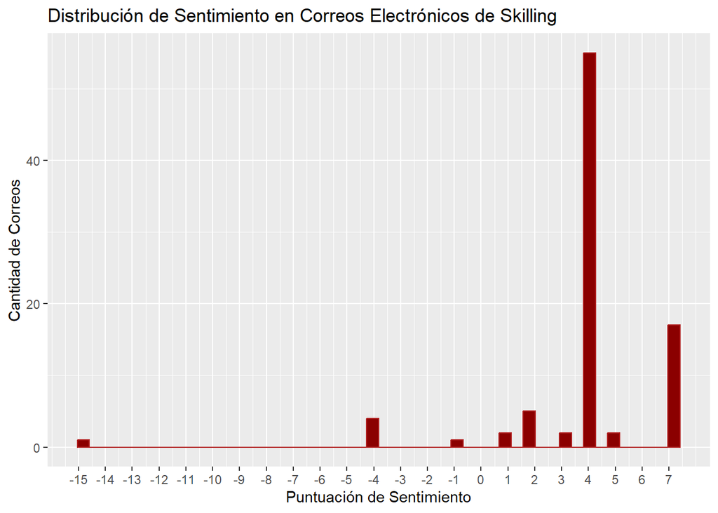

```r
# Gráfico de histograma de la puntuación de sentimiento
ggplot(data = sentiment_analysis, aes(x = sentiment_score)) +
  geom_histogram(bins = 50, color = 'firebrick', fill = 'darkred') +
  scale_x_continuous(breaks = seq(min(sentiment_analysis$sentiment_score),
                                  max(sentiment_analysis$sentiment_score), by = 1)) +
  xlab("Puntuación de Sentimiento") +
  ylab("Cantidad de Correos") +
  ggtitle("Distribución de Sentimiento en Correos Electrónicos de Skilling")
```

Podemos ver que el correo con id 6 tiene un sentimiento negativo muy grande, de -15. Vamos a analizarlo con más profundidad:

```r
# Filtramos el correo con el ID 6
correo_id_6 <- mails.skilling[mails.skilling$email_id == 6, ]

# Vemos el contenido del correo
print(correo_id_6$body)
```

```
## [1] "I ll get you guys added to the distribution list.Regards,Jeff -----Original Message-----From: \tFitzsimmons, Brendan  Sent:\tMonday, July 16, 2001 7:34 PMTo:\tShankman, Jeffrey A.; Hickerson, Gary; Hannon, Kevin; Kinneman, Jeff; Fiala, Markus; Pizzolato, Paul; Gordon, Michael; Shahi, Pushkar…
```

El correo electrónico contiene discusiones sobre la situación económica y política en Brasil y Argentina, así como sobre las medidas que se están tomando para abordar diversas crisis y desafíos. Algunos puntos que pueden causar el alto sentimiento negativo son:

- Menciones de crisis y dilemas económicos: El correo aborda la crisis económica y la difícil situación en Brasil y Argentina, discutiendo dilemas como la decisión de aumentar las tasas de interés o esperar.
- Referencias a la incertidumbre y la falta de progreso: Se menciona la incertidumbre sobre el resultado de las políticas económicas y la falta de progreso en la resolución de los problemas. Por ejemplo, se menciona al Ministro de Economía Cavallo en Argentina.
- Discusión sobre la necesidad de medidas urgentes y la falta de apoyo político: El correo menciona la necesidad de tomar medidas urgentes para abordar la crisis económica, pero también señala la falta de apoyo político para ciertas políticas propuestas.
- Menciones de problemas financieros y estrategias de recaudación de fondos: Se discuten problemas financieros, como la necesidad de recaudar impuestos por adelantado y realizar intercambios de bonos para cubrir déficits presupuestarios.

## Personas con quien Jeff Skilling se comunicaba

Vamos a estudiar con quién se ha comunicado más y menos Jeff Skilling, y analizaremos quienes eran algunas de estas personas y su papel en la empresa.

```r
# Obtenemos todos los nombres únicos de los campos de sender y receiver excluyendo a Jeff Skilling
all_names <- c(unique(mails.skilling$sender[mails.skilling$sender != "jeff.skilling@enron.com"]),
               unique(mails.skilling$receiver[mails.skilling$receiver != "jeff.skilling@enron.com"]))

# Eliminamos duplicados
all_names <- unique(all_names)

print(all_names)
```

```
##  [1] "david.w.delainey@enron.com"   "jeffrey.a.shankman@enron.com"
##  [3] "steven.j.kean@enron.com"      "jeff.dasovich@enron.com"
##  [5] "stanley.horton@enron.com"     "greg.whalley@enron.com"
##  [7] "phillip.k.ellen@enron.com"    "sally.beck@enron.com"
##  [9] "rick.buy@enron.com"           "james.derrick@enron.com"
## [11] "e..haedicke@enron.com"        "j.kaminski@enron.com"
## [13] "louise.kitchen@enron.com"     "danny.mccarty@enron.com"
## [15] "richard.shapiro@enron.com"    "kenneth.lay@enron.com"
## [17] "shelley.corman@enron.com"     "drew.fossum@enron.com"
## [19] "steven.harris@enron.com"      "kevin.m.presto@enron.com"
## [21] "james.d.steffes@enron.com"    "barry.tycholiz@enron.com"
## [23] "andy.zipper@enron.com"
```

Buscamos el número de apariciones de los receiver:

```r
# Contamos las apariciones como receiver
name_counts_receiver <- mails.skilling %>%
  filter(receiver != "jeff.skilling@enron.com") %>%
  count(receiver) %>%
  rename(name = receiver, counts = n)
```

Buscamos el número de apariciones de los sender:

```r
# Contamos las apariciones como sender
name_counts_sender <- mails.skilling %>%
  filter(sender != "jeff.skilling@enron.com") %>%
  count(sender) %>%
  rename(name = sender, counts = n)
```

Combinamos el número de apariciones de receiver y sender:

```r
# Combinamos los recuentos de sender y receiver
name_counts <- data.frame(name = all_names) %>%
  left_join(name_counts_sender, by = "name") %>%
  left_join(name_counts_receiver, by = "name") %>%
  replace_na(list(counts.x = 0, counts.y = 0))
```

Obtenemos el total de apariciones de receiver y sender:

```r
# Sumamos los recuentos para obtener un total
name_counts$total_counts <- rowSums(name_counts[, c("counts.x", "counts.y")], na.rm = TRUE)
```

```r
# Ordenamos por el total de apariciones de forma descendente y eliminamos duplicados
distinct_counts <- name_counts %>%
  arrange(desc(total_counts)) %>%
  distinct(name, .keep_all = TRUE)

# Mostramos los resultados
print(distinct_counts)
```

```
##                            name counts.x counts.y total_counts
## 1       steven.j.kean@enron.com        5        4            9
## 2      stanley.horton@enron.com        5        4            9
## 3  jeffrey.a.shankman@enron.com        4        4            8
## 4         kenneth.lay@enron.com        0        8            8
## 5    david.w.delainey@enron.com        2        4            6
## 6        greg.whalley@enron.com        1        4            5
## 7     phillip.k.ellen@enron.com        0        4            4
## 8          sally.beck@enron.com        0        4            4
## 9            rick.buy@enron.com        0        4            4
## 10      james.derrick@enron.com        0        4            4
## 11        e..haedicke@enron.com        0        4            4
## 12         j.kaminski@enron.com        0        4            4
## 13     louise.kitchen@enron.com        0        4            4
## 14      danny.mccarty@enron.com        0        4            4
## 15    richard.shapiro@enron.com        0        4            4
## 16      jeff.dasovich@enron.com        2        0            2
## 17     shelley.corman@enron.com        0        1            1
## 18        drew.fossum@enron.com        0        1            1
## 19      steven.harris@enron.com        0        1            1
## 20     kevin.m.presto@enron.com        0        1            1
## 21    james.d.steffes@enron.com        0        1            1
## 22     barry.tycholiz@enron.com        0        1            1
## 23        andy.zipper@enron.com        0        1            1
```

Podemos analizar la relación de Skilling con alguna de estas personas y su papel en la empresa:

1. **Steven J. Kean**: Siendo uno de los que más interacciones tuvo con Skilling, Kean fue eventualmente el Jefe de Personal en Enron, lo que implicaría que su comunicación frecuente con Skilling fue relevante para la toma de decisiones en la empresa.
2. **Stanley Horton**: Con un número de interacciones igual que Kean, Horton fue Presidente de Enron Gas Pipeline Group, y podemos ver que mantenía mucha comunicación con Skilling, posiblemente discutiendo asuntos relacionados con las operaciones de pipeline y su optimización.
3. **Kenneth Lay**: Como el CEO de Enron, la fuerte comunicación con Skilling (que era el COO y luego el CEO) tiene mucho sentido. Es el que más correos recibe de Jeff Skilling.
4. **Greg Whalley**: Con una cantidad menor pero aún asi significativa de intercambios, Whalley, que fue Presidente y COO de Enron, seguramente trató temas operacionales y estratégicos con Skilling.
5. **Rick Buy**: Presenta menos correos con Skilling, pero como Chief Risk Officer, Buy podría haber estado involucrado en la comunicación sobre la gestión de riesgos y la toma de decisiones financieras estratégicas.
6. **Louise Kitchen**: Su comunicación con Skilling, aunque no tan frecuente, podría haber sido significativa debido a su papel en la creación y gestión de Enron Online, la plataforma de comercio en línea de la compañía.
7. **Jeff Dasovich**: Aunque parece haber tenido menos interacción, como ejecutivo implicado en las regulaciones gubernamentales y asuntos públicos, sus correos probablemente se relacionaron con la estrategia de Enron frente a la regulación y la política energética. Aún así, me ha sorprendido la poca cantidad de correos que Skilling intercambiaba con Dasovich.

## Temas tratados en algunos correos

Primero, analizamos la estructura y la información de los datos donde tenemos los emails enviados y recibidos por Jeff Skilling:

```r
# Vemos las primeras filas del dataframe para inspeccionar los datos
head(mails.skilling)
```

```
##                             sender                receiver type
## 28666   david.w.delainey@enron.com jeff.skilling@enron.com   TO
## 60834   david.w.delainey@enron.com jeff.skilling@enron.com   TO
## 60835 jeffrey.a.shankman@enron.com jeff.skilling@enron.com   TO
## 60836 jeffrey.a.shankman@enron.com jeff.skilling@enron.com   TO
## 25327      steven.j.kean@enron.com jeff.skilling@enron.com   TO
## 60837 jeffrey.a.shankman@enron.com jeff.skilling@enron.com   TO
##                                        subject
## 28666                         More UC/CSU Info
## 60834                         More UC/CSU Info
## 60835 FW: Please Read - Argentina/Brazil Alert
## 60836
## 25327               California Update--0717.01
## 60837              FW: Brazil/Argentina Update
##                                                                                                                                                                                                                                                                                                          …
## 28666                                                                                                                                                                                                                                                                                                    …
## 60834                                                                                                                                                                                                                                                                                                    …
## 60835                                                                                                                                                                                                                                                                                                    …
## 60836                                                                                                                                                                                                                                                                                                    …
## 25327                                                                                                                                                                                                                                                                                                    …
## 60837 I ll get you guys added to the distribution list.Regards,Jeff -----Original Message-----From: \tFitzsimmons, Brendan  Sent:\tMonday, July 16, 2001 7:34 PMTo:\tShankman, Jeffrey A.; Hickerson, Gary; Hannon, Kevin; Kinneman, Jeff; Fiala, Markus; Pizzolato, Paul; Gordon, Michael; Shahi, Pushka…
##                      date              date.R email_id
## 28666 2001-07-12 04:36:58 2001-07-12 04:36:58        1
## 60834 2001-07-12 04:36:58 2001-07-12 04:36:58        2
## 60835 2001-07-12 10:55:09 2001-07-12 10:55:09        3
## 60836 2001-07-16 10:05:19 2001-07-16 10:05:19        4
## 25327 2001-07-18 00:17:00 2001-07-18 00:17:00        5
## 60837 2001-07-17 06:45:36 2001-07-17 06:45:36        6
```

```r
# Obtenemos un resumen de la estructura del dataframe con la función str()
str(mails.skilling)
```

```
## 'data.frame':    90 obs. of  8 variables:
##  $ sender  : chr  "david.w.delainey@enron.com" "david.w.delainey@enron.com" "jeffrey.a.shankman@enron.com" "jeffrey.a.shankman@enron.com" ...
##  $ receiver: chr  "jeff.skilling@enron.com" "jeff.skilling@enron.com" "jeff.skilling@enron.com" "jeff.skilling@enron.com" ...
##  $ type    : chr  "TO" "TO" "TO" "TO" ...
##  $ subject : chr  "More UC/CSU Info" "More UC/CSU Info" "FW: Please Read - Argentina/Brazil Alert" "" ...
##  $ body    : chr  "---------------------- Forwarded by David W Delainey/HOU/EES on 07/12/2001 06:36 AM ---------------------------"| __truncated__ "---------------------- Forwarded by David W Delainey/HOU/EES on 07/12/2001 06:36 AM ---------------------------"| __truncated__ "Jeff, great job this…
##  $ date    : chr  "2001-07-12 04:36:58" "2001-07-12 04:36:58" "2001-07-12 10:55:09" "2001-07-16 10:05:19" ...
##  $ date.R  : POSIXct, format: "2001-07-12 04:36:58" "2001-07-12 04:36:58" ...
##  $ email_id: int  1 2 3 4 5 6 7 8 9 10 ...
```

```r
# Obtenemos un resumen de cada columna con la función summary()
summary(mails.skilling)
```

```
##     sender            receiver             type             subject
##  Length:90          Length:90          Length:90          Length:90
##  Class :character   Class :character   Class :character   Class :character
##  Mode  :character   Mode  :character   Mode  :character   Mode  :character
##
##
##
##      body               date               date.R
##  Length:90          Length:90          Min.   :2001-07-12 04:36:58.000
##  Class :character   Class :character   1st Qu.:2001-08-01 12:25:58.000
##  Mode  :character   Mode  :character   Median :2001-08-01 12:25:58.000
##                                        Mean   :2001-07-30 20:20:23.055
##                                        3rd Qu.:2001-08-01 14:01:10.000
##                                        Max.   :2001-08-07 07:20:12.000
##     email_id
##  Min.   : 1.00
##  1st Qu.:23.25
##  Median :45.50
##  Mean   :45.50
##  3rd Qu.:67.75
##  Max.   :90.00
```

```r
# Antes de elegir los id para estudiar algunos emails, voy a analizarlos por encima para elegir los más interesantes
view(mails.skilling)
```

Vamos a analizar tres correos que me han parecido interesantes:

### Correo 1

```r
# Indentificamos el correo electronico
email_60835 <- mails.skilling[rownames(mails.skilling) == 60835,]
print(email_60835)
```

```
##                             sender                receiver type
## 60835 jeffrey.a.shankman@enron.com jeff.skilling@enron.com   TO
##                                        subject
## 60835 FW: Please Read - Argentina/Brazil Alert
##                                                                                                                                                                                                                                                                                                          …
## 60835 Jeff, great job this morning on CNBC.  You were on during our morning crude/products meeting, and the guys were clapping adn doing the old Arsenio Hall thing at the end of the interview... We get these South American reports frequently from our competitive intelligence group, and they are u…
##                      date              date.R email_id
## 60835 2001-07-12 10:55:09 2001-07-12 10:55:09        3
```

```r
# Analizamos el contenido
body_60835 <- mails.skilling$body[rownames(mails.skilling) == 60835]
print(body_60835)
```

```
## [1] "Jeff, great job this morning on CNBC.  You were on during our morning crude/products meeting, and the guys were clapping adn doing the old Arsenio Hall thing at the end of the interview... We get these South American reports frequently from our competitive intelligence group, and they are us…
```

Este correo, enviado por Jeffrey Shankman, felicita a Jeff Skilling por su presentación en CNBC y sugiere compartir informes detallados sobre Sudamérica. Aborda la inestabilidad en Argentina y la falta de apoyo internacional, enfocándose en la estrategia de EE.UU. de priorizar el apoyo a Brasil sobre Argentina para estabilizar la región y por intereses políticos y económicos relacionados con México.

### Correo 2

```r
# Indentificamos el correo electronico
email_60836 <- mails.skilling[rownames(mails.skilling) == 60836,]
print(email_60836)
```

```
##                             sender                receiver type subject
## 60836 jeffrey.a.shankman@enron.com jeff.skilling@enron.com   TO
##                                                                                                                                                                                                                                                                                                          …
## 60836 Hi Jeff, hope the weekend was great.With all the management and business changes in the organization the last few months, it might not be a bad idea to get everyone (say OOC at business units and higher, or like the old EI/ENA MD meeting in Cabo) to an offsite to do business reviews, and do…
##                      date              date.R email_id
## 60836 2001-07-16 10:05:19 2001-07-16 10:05:19        4
```

```r
# Analizamos el contenido
body_60836 <- mails.skilling$body[rownames(mails.skilling) == 60836]
print(body_60836)
```

```
## [1] "Hi Jeff, hope the weekend was great.With all the management and business changes in the organization the last few months, it might not be a bad idea to get everyone (say OOC at business units and higher, or like the old EI/ENA MD meeting in Cabo) to an offsite to do business reviews, and do …
```

Jeffrey Shankman envió un correo a Jeff Skilling sugiriendo una reunión fuera de la oficina con altos ejecutivos para revisar negocios y estrategias, y expresó interés en alejarse y dialogar con el equipo durante un par de días.

### Correo 3

```r
# Indentificamos el correo electronico
email_60845 <- mails.skilling[rownames(mails.skilling) == 60845,]
print(email_60845)
```

```
##                             sender                receiver type subject
## 60845 jeffrey.a.shankman@enron.com jeff.skilling@enron.com   TO
##                                   body                date              date.R
## 60845 Congrats on your engagement!Jeff 2001-07-30 10:09:13 2001-07-30 10:09:13
##       email_id
## 60845       14
```

```r
# Analizamos el contenido
body_60845 <- mails.skilling$body[rownames(mails.skilling) == 60845]
print(body_60845)
```

```
## [1] "Congrats on your engagement!Jeff"
```

Este correo es un poco diferente a los demás, pero me ha sorprendido porque Jeffrey Shankman envió un mensaje breve y personal a Jeff Skilling para felicitarlo por su compromiso.

No intencionadamente, me he dado cuenta de que los tres correos que he analizado son entre Jeffrey Shankman y Jeff Skilling, lo que tiene lógica porque era el tercero con el que más se comunicaba. Además, podemos ver que tenían una relación tal vez más cercana que con otros empleados, como podemos ver reflejado en este último correo.

También me he dado cuenta de que en los correos enviados por Jeff Skilling, hay muchas invitaciones a reuniones a sus empleados, ya que estos correos son del 7 de agosto de 2001, cuando todavía era CEO de Enron.

Estas invitaciones son los últimos correos que aparecen enviados o recibidos por Jeff Skilling, lo que tiene sentido porque renunció a su puesto como CEO de Enron el 14 de agosto de 2001.

# Reciprocidad y grafo social

Analizamos de la reciprocidad en la red y examinamos las díadas (pares de nodos):

```r
print("Reciprodicad:")
```

```
## [1] "Reciprodicad:"
```

```r
# La función 'reciprocity' calcula la proporción de aristas en la red que son recíprocas
reciprocity(network.full)
```

```
## [1] 0.4291992
```

```r
print("Diadas:")
```

```
## [1] "Diadas:"
```

```r
# La función 'dyad.census' cuenta el número de díadas mutuas, asimétricas y nulas en la red
dyad.census(network.full)
```

```
## $mut
## [1] 761
##
## $asym
## [1] 968
##
## $null
## [1] 9297
```

La función reciprocity muestra que aproximadamente el 42.92% de las aristas en la red son recíprocas, lo que indica que un poco menos de la mitad de todas las comunicaciones tienen correspondencia en ambas direcciones (es decir, si A se comunica con B, B también se comunica con A).

El dyad.census proporciona un desglose de los diferentes tipos de díadas que se encuentran en la red:

- Mutuas (mut): 761 pares de nodos tienen aristas en ambas direcciones, lo que significa que hay una relación recíproca entre ellos.
- Asimétricas (asym): 968 pares de nodos tienen una relación en una sola dirección (A se comunica con B, pero B no se comunica con A o viceversa).
- Nulas (null): 9297 pares de nodos no tienen ninguna conexión entre ellos.

Preparamos la red para convertirla de un grafo de comunicaciones (basado en correos electrónicos) a un grafo social (basado en diadas). En un grafo social, se requiere que las relaciones sean recíprocas para considerarse una relación social.

```r
# Extraemos pares únicos de comunicación y los ordenamos
pairs <- as.data.frame(unique(edges.full[c(1,2)]))
pairs <- pairs[order(pairs$sender, pairs$receiver),]

# Ordenamos las aristas también por emisor y receptor
edges.ordered <- edges.full[order(edges.full$sender, edges.full$receiver),]

# Agregamos las aristas para calcular el peso de la comunicación entre dos nodos y los ordenamos
weight <- aggregate(edges.ordered[,3],
                    by = list(edges.ordered[,1], edges.ordered[,2]),
                    length)
weight <- weight[order(weight$Group.1, weight$Group.2),]
```

Verificamos que los datos estén ordenados y coincidan correctamente:

```r
head(pairs, n = 5L)
```

```
##                        sender                receiver
## 51982 albert.meyers@enron.com bill.williams@enron.com
## 51981 albert.meyers@enron.com  ryan.slinger@enron.com
## 50480   andrea.ring@enron.com    brad.mckay@enron.com
## 50482   andrea.ring@enron.com chris.germany@enron.com
## 50508   andrea.ring@enron.com  gerald.nemec@enron.com
```

```r
head(weight, n = 5L)
```

```
##                      Group.1                 Group.2 x
## 96   albert.meyers@enron.com bill.williams@enron.com 5
## 2039 albert.meyers@enron.com  ryan.slinger@enron.com 2
## 111    andrea.ring@enron.com    brad.mckay@enron.com 1
## 187    andrea.ring@enron.com chris.germany@enron.com 1
## 622    andrea.ring@enron.com  gerald.nemec@enron.com 1
```

```r
tail(pairs, n = 5L)
```

```
##                        sender                   receiver
## 51179 vladi.pimenov@enron.com     geoff.storey@enron.com
## 51183 vladi.pimenov@enron.com       jane.tholt@enron.com
## 50723 vladi.pimenov@enron.com    john.griffith@enron.com
## 51174 vladi.pimenov@enron.com   jonathan.mckay@enron.com
## 51176 vladi.pimenov@enron.com sandra.f.brawner@enron.com
```

```r
tail(weight, n = 5L)
```

```
##                      Group.1                    Group.2 x
## 621  vladi.pimenov@enron.com     geoff.storey@enron.com 1
## 835  vladi.pimenov@enron.com       jane.tholt@enron.com 1
## 1053 vladi.pimenov@enron.com    john.griffith@enron.com 4
## 1099 vladi.pimenov@enron.com   jonathan.mckay@enron.com 4
## 2084 vladi.pimenov@enron.com sandra.f.brawner@enron.com 2
```

```r
pairs[seq(236:248),]
```

```
##                        sender                    receiver
## 51982 albert.meyers@enron.com     bill.williams@enron.com
## 51981 albert.meyers@enron.com      ryan.slinger@enron.com
## 50480   andrea.ring@enron.com        brad.mckay@enron.com
## 50482   andrea.ring@enron.com     chris.germany@enron.com
## 50508   andrea.ring@enron.com      gerald.nemec@enron.com
## 50483   andrea.ring@enron.com     judy.townsend@enron.com
## 50484   andrea.ring@enron.com      peter.keavey@enron.com
## 50467   andrea.ring@enron.com      richard.ring@enron.com
## 50470   andrea.ring@enron.com  sandra.f.brawner@enron.com
## 50481   andrea.ring@enron.com scott.hendrickson@enron.com
## 50468   andrea.ring@enron.com        scott.neal@enron.com
## 51805   andy.zipper@enron.com    barry.tycholiz@enron.com
## 16708   andy.zipper@enron.com        brad.mckay@enron.com
```

```r
weight[seq(236:248),]
```

```
##                      Group.1                     Group.2  x
## 96   albert.meyers@enron.com     bill.williams@enron.com  5
## 2039 albert.meyers@enron.com      ryan.slinger@enron.com  2
## 111    andrea.ring@enron.com        brad.mckay@enron.com  1
## 187    andrea.ring@enron.com     chris.germany@enron.com  1
## 622    andrea.ring@enron.com      gerald.nemec@enron.com  1
## 1109   andrea.ring@enron.com     judy.townsend@enron.com  1
## 1825   andrea.ring@enron.com      peter.keavey@enron.com  1
## 1928   andrea.ring@enron.com      richard.ring@enron.com 22
## 2066   andrea.ring@enron.com  sandra.f.brawner@enron.com 16
## 2101   andrea.ring@enron.com scott.hendrickson@enron.com  1
## 2108   andrea.ring@enron.com        scott.neal@enron.com  1
## 39     andy.zipper@enron.com    barry.tycholiz@enron.com  3
## 112    andy.zipper@enron.com        brad.mckay@enron.com  3
```

Combinamos los pares con su respectivo peso:

```r
# Combinamos y mostramos los primeros
pairs$weight <- weight$x
head(pairs)
```

```
##                        sender                receiver weight
## 51982 albert.meyers@enron.com bill.williams@enron.com      5
## 51981 albert.meyers@enron.com  ryan.slinger@enron.com      2
## 50480   andrea.ring@enron.com    brad.mckay@enron.com      1
## 50482   andrea.ring@enron.com chris.germany@enron.com      1
## 50508   andrea.ring@enron.com  gerald.nemec@enron.com      1
## 50483   andrea.ring@enron.com judy.townsend@enron.com      1
```

Cada fila en pairs corresponde a un par único de remitente y receptor en la red, y la columna “weight” ahora contiene el peso del enlace entre estos pares de nodos.

Creamos un nuevo grafo utilizando la tabla de pares con pesos como aristas y los nodos como vértices:

```r
# Creamos el grafo
network.sna <- graph.data.frame(pairs,
                                directed = TRUE,
                                vertices = nodes_rich)
# Mostramos un resumen del grafo
summary(network.sna)
```

```
## IGRAPH 5bc4f95 DNW- 149 2490 --
## + attr: name (v/c), email_id_sin_arroba (v/c), lastName (v/c), status.x
## | (v/c), nombre_completo (v/c), status.y (v/c), role (v/c), weight
## | (e/n)
```

Comprobamos la reciprocidad y el censo de díadas en el nuevo grafo:

```r
reciprocity(network.sna)
```

```
## [1] 0.611245
```

```r
dyad.census(network.sna)
```

```
## $mut
## [1] 761
##
## $asym
## [1] 968
##
## $null
## [1] 9297
```

Las diadas son las mismas que en network.full, lo que tiene sentido porque este nuevo parte de él.

Exportamos el grafo social para su posterior análisis en Gephi:

```r
# Para imponer que una arista sea recíproca y exista una relación social, convertimos el grafo dirigido a uno no dirigido
network.social <- as.undirected(network.sna,
                                mode = "collapse",
                                edge.attr.comb = "sum")

# Exportamos el grafo social a un archivo en formato GraphML para visualización en Gephi
write.graph(network.social, file = "network_social_enron.graphml", format = "graphml")
```

```r
# Guardamos el entorno de trabajo
save.image("03_grafo_social.rda")
```

# Comunidades

Antes de calcular las comunidades:

```r
# Utilizamos el algoritmo de Louvain para detectar comunidades en el grafo
communities <- multilevel.community(network.social)

# Creamos un dataframe para almacenar los resultados de las comunidades
comms.df <- data.frame(row.names = seq(1:149))
comms.df$Email_id <- communities$names  # Asignamos identificadores de correo/nodos a 'Email_id'
comms.df$community <- communities$membership  # Asignamos membresía de la comunidad a cada nodo
```

Añadimos la información de la comunidad al dataframe de nodos existente:

```r
nodes.def <- merge(nodes_rich, comms.df,
                   by.x = "Email_id",
                   by.y = "Email_id")

# Exploramos la estructura del dataframe actualizado con las comunidades
str(nodes.def)
```

```
## 'data.frame':    149 obs. of  8 variables:
##  $ Email_id           : chr  "albert.meyers@enron.com" "andrea.ring@enron.com" "andy.zipper@enron.com" "barry.tycholiz@enron.com" ...
##  $ email_id_sin_arroba: chr  "albert.meyers" "andrea.ring" "andy.zipper" "barry.tycholiz" ...
##  $ lastName           : chr  "Meyers" "Ring" "Zipper" "Tycholiz" ...
##  $ status.x           : chr  "Employee" "N/A" "Vice President" "Vice President" ...
##  $ nombre_completo    : chr  "Albert Meyers" "Andrea Ring" "Andy Zipper" "Barry Tycholiz" ...
##  $ status.y           : chr  "Employee" "N/A" "Vice President" "Vice President" ...
##  $ role               : chr  "Specialist" "" "Enron Online" "" ...
##  $ community          : num  1 2 2 3 2 4 1 2 5 1 ...
```

```r
# Vemos las primeras entradas del dataframe actualizado
head(nodes.def)
```

```
##                    Email_id email_id_sin_arroba lastName       status.x
## 1   albert.meyers@enron.com       albert.meyers   Meyers       Employee
## 2     andrea.ring@enron.com         andrea.ring     Ring            N/A
## 3     andy.zipper@enron.com         andy.zipper   Zipper Vice President
## 4  barry.tycholiz@enron.com      barry.tycholiz Tycholiz Vice President
## 5 benjamin.rogers@enron.com     benjamin.rogers   Rogers       Employee
## 6       bill.rapp@enron.com           bill.rapp     Rapp            N/A
##   nombre_completo       status.y         role community
## 1   Albert Meyers       Employee   Specialist         1
## 2     Andrea Ring            N/A                      2
## 3     Andy Zipper Vice President Enron Online         2
## 4  Barry Tycholiz Vice President                      3
## 5 Benjamin Rogers       Employee    Associate         2
## 6       Bill Rapp            N/A                      4
```

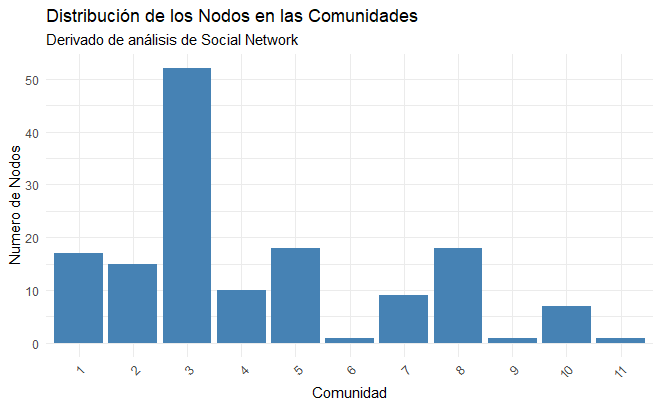

```r
# Creamos una tabla de frecuencias para las comunidades
community_counts <- as.data.frame(table(nodes.def$community))

# Usamos ggplot2 para hacer un gráfico de barras
ggplot(community_counts, aes(x = Var1, y = Freq)) +
  geom_bar(stat = "identity", fill = "steelblue") +  # Dibujamos las barras
  labs(x = "Comunidad", y = "Numero de Nodos",  # Etiquetas para los ejes
       title = "Distribución de los Nodos en las Comunidades",
       subtitle = "Derivado de análisis de Social Network") +
  theme_minimal() +
  theme(axis.text.x = element_text(angle = 45, hjust = 1)) # Rotamos las etiquetas del eje x

# Añadimos la membresía de la comunidad a los nodos en el objeto igraph
V(network.social)$community <- communities$membership
```

```r
# Guardamos el entorno de trabajo
save.image("04_comunidades.rda")
```

# Análisis de la comunidad 3

```r
# Inicializamos el número de comunidad de Skilling como NA para manejar el caso de que no se encuentre
skilling_community_number <- NA

# Iteramos a través de cada comunidad para encontrar el correo electrónico de Skilling
for (community_number in seq_along(communities)) {
  if ("jeff.skilling@enron.com" %in% communities[[community_number]]) {
    skilling_community_number <- community_number
    break  # Dejamos de iterar una vez se encuentre a Skilling
  }
}

# Verificamos si encontramos a Skilling en alguna comunidad
if (!is.na(skilling_community_number)) {
  print(paste("Jeffrey Skilling está en la comunidad número:", skilling_community_number))
} else {
  print("Jeffrey Skilling no se encontró en ninguna comunidad.")
}
```

```
## [1] "Jeffrey Skilling está en la comunidad número: 2"
```

Filtramos los miembros de la Comunidad 3 del dataframe que contiene la membresía de la comunidad:

```r
# Filtramos para obtener solo los miembros de la Comunidad 3
community_3 <- subset(nodes.def, community == 3)
```

Analizamos la Estructura y Roles de la Comunidad:

```r
# Resumen de cargos y roles dentro de la Comunidad 3
table(community_3$role)
```

```
##
##
## 8
```

```r
table(community_3$position)
```

```
## < table of extent 0 >
```

Calculamos métricas de redes para cada miembro de la Comunidad 3 como la centralidad de grado, cercanía, y betweenness, que pueden indicar la importancia de cada individuo dentro de la comunidad:

```r
# Subgrafo de la Comunidad 3
community_3_subgraph <- induced_subgraph(network.social,
                                         V(network.social)$name %in% community_3$Email_id)

# Calculamos las métricas para el subgrafo
community_3_degrees <- degree(community_3_subgraph)
community_3_closeness <- closeness(community_3_subgraph)
community_3_betweenness <- betweenness(community_3_subgraph)

# Imprimimos las métricas de grado
print("Grados de la Comunidad 3:")
```

```
## [1] "Grados de la Comunidad 3:"
```

```r
print(community_3_degrees)
```

```
##    barry.tycholiz@enron.com          dan.hyvl@enron.com
##                           8                           8
## debra.perlingiere@enron.com      gerald.nemec@enron.com
##                           9                           8
##    jason.williams@enron.com          kim.ward@enron.com
##                           9                           7
##        mark.whitt@enron.com    patrice.l.mims@enron.com
##                           8                           3
##        paul.lucci@enron.com     theresa.staab@enron.com
##                           8                           6
```

```r
# Imprimimos las métricas de cercanía
print("Cercanía de la Comunidad 3:")
```

```
## [1] "Cercanía de la Comunidad 3:"
```

```r
print(community_3_closeness)
```

```
##    barry.tycholiz@enron.com          dan.hyvl@enron.com
##                 0.015873016                 0.014705882
## debra.perlingiere@enron.com      gerald.nemec@enron.com
##                 0.009259259                 0.006369427
##    jason.williams@enron.com          kim.ward@enron.com
##                 0.018867925                 0.010526316
##        mark.whitt@enron.com    patrice.l.mims@enron.com
##                 0.012658228                 0.015151515
##        paul.lucci@enron.com     theresa.staab@enron.com
##                 0.012195122                 0.017543860
```

```r
# Imprimimos las métricas de betweenness
print("Intermediación de la Comunidad 3:")
```

```
## [1] "Intermediación de la Comunidad 3:"
```

```r
print(community_3_betweenness)
```

```
##    barry.tycholiz@enron.com          dan.hyvl@enron.com
##                           7                           5
## debra.perlingiere@enron.com      gerald.nemec@enron.com
##                           0                           0
##    jason.williams@enron.com          kim.ward@enron.com
##                          22                           0
##        mark.whitt@enron.com    patrice.l.mims@enron.com
##                           8                           5
##        paul.lucci@enron.com     theresa.staab@enron.com
##                           0                          13
```

Interpretamos las métricas en el contexto de los roles y cargos: Los individuos con mayor centralidad pueden ser puntos clave en la difusión de información, y aquellos con roles o cargos de alto nivel podrían tener un impacto significativo en la dinámica de la comunidad.

```r
# Añadimos las métricas al dataframe de la comunidad
community_3$degree <- community_3_degrees[V(community_3_subgraph)$name]
community_3$closeness <- community_3_closeness[V(community_3_subgraph)$name]
community_3$betweenness <- community_3_betweenness[V(community_3_subgraph)$name]

# Analizamos los datos
summary(community_3)
```

```
##    Email_id         email_id_sin_arroba   lastName           status.x
##  Length:10          Length:10           Length:10          Length:10
##  Class :character   Class :character    Class :character   Class :character
##  Mode  :character   Mode  :character    Mode  :character   Mode  :character
##
##
##
##  nombre_completo      status.y             role             community
##  Length:10          Length:10          Length:10          Min.   :3
##  Class :character   Class :character   Class :character   1st Qu.:3
##  Mode  :character   Mode  :character   Mode  :character   Median :3
##                                                           Mean   :3
##                                                           3rd Qu.:3
##                                                           Max.   :3
##      degree       closeness         betweenness
##  Min.   :3.00   Min.   :0.006369   Min.   : 0.00
##  1st Qu.:7.25   1st Qu.:0.010944   1st Qu.: 0.00
##  Median :8.00   Median :0.013682   Median : 5.00
##  Mean   :7.40   Mean   :0.013315   Mean   : 6.00
##  3rd Qu.:8.00   3rd Qu.:0.015693   3rd Qu.: 7.75
##  Max.   :9.00   Max.   :0.018868   Max.   :22.00
```

Visualizamos la red de la comunidad 3:

```r
# Exportamos el grafo de la comunidad a un archivo en formato GraphML para visualización en Gephi
write.graph(community_3_subgraph, file = "network_community_3.graphml", format = "graphml")
```

**Nota:** el análisis de este grafo se encuentra en el word adjuntado en la entrega.

Análisis de interacciones:

[figure not shown]

```r
# Definimos el tamaño del gráfico
par(oma=c(8,5,5,10))

# Calculamos la matriz de adyacencia para identificar patrones de interacción
adj_matrix_com_3 <- as_adjacency_matrix(community_3_subgraph, attr = "weight", sparse = FALSE)

# Creamos un heatmap basado en la matriz de adyacencia
heatmap(adj_matrix_com_3,
        Rowv = NA, Colv = NA,     # No mostrar dendrogramas
        scale = "none",           # No escalar los datos
        main = "Heatmap de Interacciones en la comunidad 3",
        cex.lab = 0.1             # Tamaño para las etiquetas de los ejes x e y
        )
```

En el heatmap, cada casilla representa la intensidad de las interacciones entre dos individuos a través de correos electrónicos. Las filas y columnas están etiquetadas con direcciones de correo electrónico de empleados de Enron. Cuanto más oscuro sea el color de una casilla, mayor será la cantidad de interacciones entre los dos individuos correspondientes.

Análisis de influencia:

```r
# Calculamos métricas de PageRank para identificar nodos influyentes
pagerank_scores_com_3 <- page_rank(community_3_subgraph)$vector

# Visualizamos nodos más influyentes en la comunidad 3
top_influential_com_3 <- names(head(sort(pagerank_scores_com_3, decreasing = TRUE), 5))
print("Nodos más influyentes en la comunidad 3:")
```

```
## [1] "Nodos más influyentes en la comunidad 3:"
```

```r
print(top_influential_com_3)
```

```
## [1] "gerald.nemec@enron.com"      "debra.perlingiere@enron.com"
## [3] "mark.whitt@enron.com"        "barry.tycholiz@enron.com"
## [5] "kim.ward@enron.com"
```

## Conclusiones de la actividad de la comunidad 3

# Análisis de la comunidad 1

He decidido analizar a fondo la comunidad 1, porque, como podemos ver en el gráfico de arriba, es una comunidad que no tiene muchos nodos, lo que nos facilitará el análisis de las comunicaciones, pero tampoco es la que menos nodos tiene, de forma que podremos estudiar suficientes comunicaciones.

Filtramos los miembros de la Comunidad 1 del dataframe que contiene la membresía de la comunidad:

```r
# Filtramos para obtener solo los miembros de la Comunidad 1
community_1 <- subset(nodes.def, community == 1)
```

Analizamos la Estructura y Roles de la Comunidad:

```r
# Resumen de cargos y roles dentro de la Comunidad 1
table(community_1$role)
```

```
##
##                                         Analyst Analyst Risk Management
##                       7                       1                       1
##            Cash Analyst     Senior Analyst Cash              Specialist
##                       1                       1                       1
##           Sr.Specialist
##                       1
```

```r
table(community_1$position)
```

```
## < table of extent 0 >
```

Calculamos métricas de redes para cada miembro de la Comunidad 1 como la centralidad de grado, cercanía, y betweenness, que pueden indicar la importancia de cada individuo dentro de la comunidad:

```r
# Subgrafo de la Comunidad 1
community_1_subgraph <- induced_subgraph(network.social,
                                         V(network.social)$name %in% community_1$Email_id)

# Calculamos las métricas para el subgrafo
community_1_degrees <- degree(community_1_subgraph)
community_1_closeness <- closeness(community_1_subgraph)
community_1_betweenness <- betweenness(community_1_subgraph)

# Imprimimos las métricas de grado
print("Grados de la Comunidad 1:")
```

```
## [1] "Grados de la Comunidad 1:"
```

```r
print(community_1_degrees)
```

```
##    albert.meyers@enron.com    bill.williams@enron.com
##                          3                         14
##   cara.semperger@enron.com       craig.dean@enron.com
##                         12                          7
##   diana.scholtes@enron.com      eric.linder@enron.com
##                          8                          3
##     geir.solberg@enron.com holden.salisbury@enron.com
##                          9                         10
##       kate.symes@enron.com        lisa.gang@enron.com
##                         13                          5
##      mark.guzman@enron.com      matt.motley@enron.com
##                          8                          5
## monika.causholli@enron.com  phillip.platter@enron.com
##                          7                          6
##     ryan.slinger@enron.com    sean.crandall@enron.com
##                         10                          6
##    steven.merris@enron.com
##                          2
```

```r
# Imprimimos las métricas de cercanía
print("Cercanía de la Comunidad 1:")
```

```
## [1] "Cercanía de la Comunidad 1:"
```

```r
print(community_1_closeness)
```

```
##    albert.meyers@enron.com    bill.williams@enron.com
##                0.015873016                0.012820513
##   cara.semperger@enron.com       craig.dean@enron.com
##                0.014705882                0.017857143
##   diana.scholtes@enron.com      eric.linder@enron.com
##                0.011494253                0.008474576
##     geir.solberg@enron.com holden.salisbury@enron.com
##                0.017241379                0.015151515
##       kate.symes@enron.com        lisa.gang@enron.com
##                0.012195122                0.014925373
##      mark.guzman@enron.com      matt.motley@enron.com
##                0.012820513                0.012345679
## monika.causholli@enron.com  phillip.platter@enron.com
##                0.016949153                0.011904762
##     ryan.slinger@enron.com    sean.crandall@enron.com
##                0.013513514                0.010101010
##    steven.merris@enron.com
##                0.006097561
```

```r
# Imprimimos las métricas de betweenness
print("Intermediación de la Comunidad 1:")
```

```
## [1] "Intermediación de la Comunidad 1:"
```

```r
print(community_1_betweenness)
```

```
##    albert.meyers@enron.com    bill.williams@enron.com
##                  32.500000                  11.000000
##   cara.semperger@enron.com       craig.dean@enron.com
##                   2.000000                  47.333333
##   diana.scholtes@enron.com      eric.linder@enron.com
##                   6.000000                   0.000000
##     geir.solberg@enron.com holden.salisbury@enron.com
##                  31.500000                   9.666667
##       kate.symes@enron.com        lisa.gang@enron.com
##                   0.000000                  17.000000
##      mark.guzman@enron.com      matt.motley@enron.com
##                   0.500000                   9.000000
## monika.causholli@enron.com  phillip.platter@enron.com
##                  38.166667                   1.000000
##     ryan.slinger@enron.com    sean.crandall@enron.com
##                  32.500000                   0.000000
##    steven.merris@enron.com
##                   0.000000
```

- Centralidad de Grado: Indica el número de conexiones directas que tiene cada nodo. Los individuos con una puntuación más alta, como bill.williams@enron.com con 14 y kate.symes@enron.com con 13, son los más conectados dentro de esta comunidad.
- Centralidad de Cercanía: Refleja cómo tan cerca está un nodo de todos los otros nodos en la red. Un valor más alto indica que un individuo puede difundir información a otros miembros de la red de manera más rápida y eficiente. Craig.dean@enron.com, con un valor de aproximadamente 0.01786, es el que tiene mejor posición para acceder y distribuir información.
- Centralidad de Betweenness: Mide la frecuencia con la que un nodo actúa como puente a lo largo del camino más corto entre dos otros nodos. Un valor alto, como el de craig.dean@enron.com con 47.33 y monika.causholli@enron.com con 38.17, sugiere que controlan el flujo de información.

Interpretamos las métricas en el contexto de los roles y cargos: Los individuos con mayor centralidad pueden ser puntos clave en la difusión de información, y aquellos con roles o cargos de alto nivel podrían tener un impacto significativo en la dinámica de la comunidad.

```r
# Añadimos las métricas al dataframe de la comunidad
community_1$degree <- community_1_degrees[V(community_1_subgraph)$name]
community_1$closeness <- community_1_closeness[V(community_1_subgraph)$name]
community_1$betweenness <- community_1_betweenness[V(community_1_subgraph)$name]

# Analizamos los datos
summary(community_1)
```

```
##    Email_id         email_id_sin_arroba   lastName           status.x
##  Length:17          Length:17           Length:17          Length:17
##  Class :character   Class :character    Class :character   Class :character
##  Mode  :character   Mode  :character    Mode  :character   Mode  :character
##
##
##
##  nombre_completo      status.y             role             community
##  Length:17          Length:17          Length:17          Min.   :1
##  Class :character   Class :character   Class :character   1st Qu.:1
##  Mode  :character   Mode  :character   Mode  :character   Median :1
##                                                           Mean   :1
##                                                           3rd Qu.:1
##                                                           Max.   :1
##      degree         closeness         betweenness
##  Min.   : 2.000   Min.   :0.006098   Min.   : 0.00
##  1st Qu.: 5.000   1st Qu.:0.011905   1st Qu.: 0.50
##  Median : 7.000   Median :0.012821   Median : 9.00
##  Mean   : 7.529   Mean   :0.013204   Mean   :14.01
##  3rd Qu.:10.000   3rd Qu.:0.015152   3rd Qu.:31.50
##  Max.   :14.000   Max.   :0.017857   Max.   :47.33
```

Visualizamos la red de la comunidad 1:

```r
# Exportamos el grafo de la comunidad a un archivo en formato GraphML para visualización en Gephi
write.graph(community_1_subgraph, file = "network_community_1.graphml", format = "graphml")
```

**Nota:** el análisis de este grafo se encuentra en el word adjuntado en la entrega.

Análisis de interacciones:

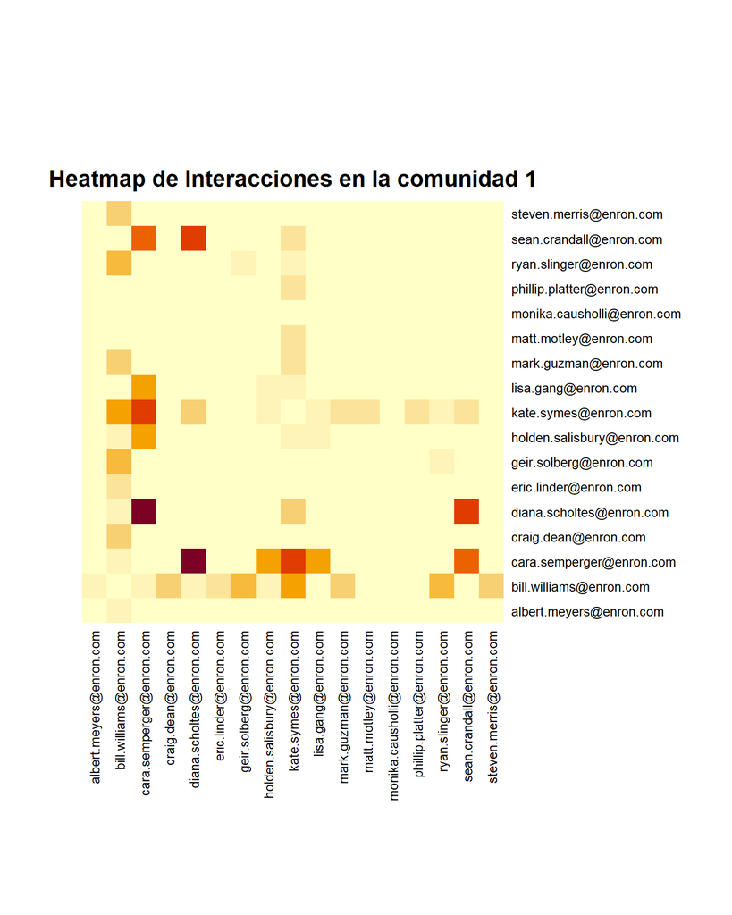

```r
# Definimos el tamaño del gráfico
par(oma=c(8,5,5,10))

# Calculamos la matriz de adyacencia para identificar patrones de interacción
adj_matrix_com_1 <- as_adjacency_matrix(community_1_subgraph, attr = "weight", sparse = FALSE)

# Creamos un heatmap basado en la matriz de adyacencia
heatmap(adj_matrix_com_1,
        Rowv = NA, Colv = NA,     # No mostrar dendrogramas
        scale = "none",           # No escalar los datos
        main = "Heatmap de Interacciones en la comunidad 1",
        cex.lab = 0.5             # Tamaño para las etiquetas de los ejes x e y
)
```

En el heatmap, cada casilla representa la intensidad de las interacciones entre dos individuos a través de correos electrónicos. Las filas y columnas están etiquetadas con direcciones de correo electrónico de empleados de Enron. Cuanto más oscuro sea el color de una casilla, mayor será la cantidad de interacciones entre los dos individuos correspondientes.

Por ejemplo, podemos ver que Diana Scholtes y Cara Semperger interaccionaron mucho, así como Diana Scholtes con Sean Crandall.

Análisis de influencia:

```r
# Calculamos métricas de PageRank para identificar nodos influyentes
pagerank_scores_com_1 <- page_rank(community_1_subgraph)$vector

# Visualizamos nodos más influyentes
top_influential_com_1 <- names(head(sort(pagerank_scores_com_1, decreasing = TRUE), 5))
print("Nodos más influyentes en la comunidad 1:")
```

```
## [1] "Nodos más influyentes en la comunidad 1:"
```

```r
print(top_influential_com_1)
```

```
## [1] "bill.williams@enron.com"  "cara.semperger@enron.com"
## [3] "kate.symes@enron.com"     "diana.scholtes@enron.com"
## [5] "sean.crandall@enron.com"
```

Analizamos el papel de estas personas en el caso Enron:

1. **Bill Williams**: Vicepresidente de comercio de Enron, implicado en transacciones controvertidas.
2. **Cara Semperger**: Empleada de Enron en el área de comercio de energía, papel exacto no tan claro.
3. **Kate Symes**: Trabajadora de recursos humanos en Enron.
4. **Diana Scholtes**: Empleada de contabilidad en Enron, papel exacto no tan claro.
5. **Sean Crandall**: Empleado de Enron en el departamento de comercio de energía, implicado en la red de comunicaciones internas de la empresa durante el escándalo Enron.

## Conclusiones de la actividad de la comunidad 1

# Análisis de momento concreto del tiempo

## Colapso de las acciones de Enron y la quiebra de Enron

El último trimestre de 2001 es crítico para entender la caída de Enron. Durante estos meses, se revelaron las prácticas contables cuestionables que llevaron a la empresa desde la cima de Wall Street a la bancarrota. En diciembre de 2001, Enron se declaró en bancarrota.

He elegido este periodo porque ofrece una visión de la reacción interna ante la crisis, por lo que es un buen escenario para estudiar la comunicación y la dinámica organizativa en momentos de colapso financiero.

```r
# Filtramos correos por fecha para enfocarnos en el último trimestre de 2001
edges.filtered <- edges.full %>%
  mutate(date.R = as.Date(date.R, format = "%Y-%m-%d %H:%M:%S")) %>%
  filter(date.R >= as.Date("2001-10-01") & date.R <= as.Date("2001-12-31"))

head(edges.filtered)
```

```
##                  sender                 receiver type
## 1 kevin.hyatt@enron.com michelle.lokay@enron.com   CC
## 2 kevin.hyatt@enron.com michelle.lokay@enron.com  BCC
## 3 kevin.hyatt@enron.com michelle.lokay@enron.com   CC
## 4 kevin.hyatt@enron.com michelle.lokay@enron.com  BCC
## 5 kevin.hyatt@enron.com  steven.harris@enron.com   TO
## 6 kevin.hyatt@enron.com   lindy.donoho@enron.com   TO
##                       subject
## 1 Response to Proposal issues
## 2 Response to Proposal issues
## 3                Panda Update
## 4                Panda Update
## 5       WSCC Power AZNMNV.xls
## 6       WSCC Power AZNMNV.xls
##                                                                                                                                                                                                                                                                                                          …
## 1 Steve, below is a partial answer to most of your questions.  Can we set a time for Wednesday afternoon 12/5 to talk?  thanksMax Hourly Quantity:  we are reviewing capability to deliver the MHQ in a 16 hr block.  Doesn t appear to be any problem but we are working thru the hydraulic studies to v…
## 2 Steve, below is a partial answer to most of your questions.  Can we set a time for Wednesday afternoon 12/5 to talk?  thanksMax Hourly Quantity:  we are reviewing capability to deliver the MHQ in a 16 hr block.  Doesn t appear to be any problem but we are working thru the hydraulic studies to v…
## 3                                                                                                                                                                                                                                                                                                        …
## 4                                                                                                                                                                                                                                                                                                        …
## 5                                                                                                                                                                                                                                                                                                        …
## 6                                                                                                                                                                                                                                                                                                        …
##                  date     date.R
## 1 2001-12-04 15:45:22 2001-12-04
## 2 2001-12-04 15:45:22 2001-12-04
## 3 2001-11-26 14:31:43 2001-11-26
## 4 2001-11-26 14:31:43 2001-11-26
## 5 2001-11-26 13:00:57 2001-11-26
## 6 2001-11-26 13:00:57 2001-11-26
```

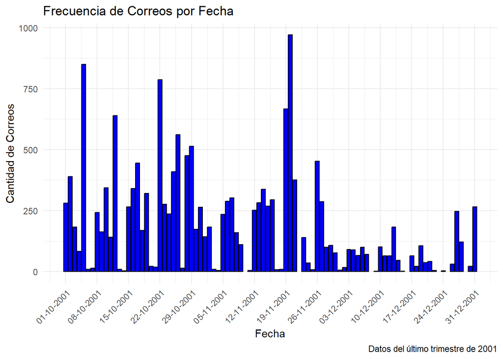

```r
# Gráfico de la frecuencia de correos por fecha
ggplot(edges.filtered, aes(x = date.R)) +
  geom_histogram(stat = "count", fill = "blue", color = "black", binwidth = 1) +  # binwidth de 1 día
  scale_x_date(date_breaks = "1 week", date_labels = "%d-%m-%Y") +
  theme_minimal() +
  labs(title = "Frecuencia de Correos por Fecha",
       x = "Fecha",
       y = "Cantidad de Correos",
       caption = "Datos del último trimestre de 2001") +
  theme(axis.text.x = element_text(angle = 45, hjust = 1))
```

Cabe destacar que la disminución de correos hacia finales de diciembre puede deberse a que Enron estaba en bancarrota, que se declaró el 2 de diciembre de 2001.

Se me ha ocurrido hacer un nuevo filtrado sobre los correos de estas fechas, filtrando los correos a partir de unas palabras clave relacionadas con el **colapso, la crisis financiera y la corrupción**:

```r
# Lista de palabras clave relacionadas con el colapso de Enron y crisis financieras
keywords <- c("bankruptcy", "fraud", "collapse", "scandal", "illegal",
              "bribery", "corruption", "insolvency", "investigation",
              "debt", "litigation", "bankrupt", "solvency", "crisis")

# Creamos una expresión regular con todas las palabras clave
keyword_pattern <- paste(keywords, collapse = "|")

# Filtramos correos que contienen alguna de las palabras clave
correos_crisis <- edges.filtered %>%
  filter(grepl(keyword_pattern, body, ignore.case = TRUE))

# Vemos los resultados filtrados
View(correos_crisis)
```

```r
# Convertimos el data frame 'correos_crisis' a un objeto de grafo
network.graph <- graph_from_data_frame(correos_crisis, directed = TRUE)

# Exportamos el grafo a un archivo en formato GraphML para visualización en Gephi
write.graph(network.graph, file = "enron_crisis_q4.graphml", format = "graphml")
```

**Nota:** el análisis de este grafo se encuentra en el word adjuntado en la entrega.

Con la función view he podido ver los correos, y he destacado algunos en los que se puede ver claramente la evidencia de la caída de Enron:

### Correo 1

```r
# Indentificamos el correo electronico
email_109 <- correos_crisis[rownames(correos_crisis) == 109,]
print(email_109)
```

```
##                    sender                  receiver type
## 109 keith.holst@enron.com phillip.k.ellen@enron.com   TO
##                                 subject
## 109 Suggested course in uncertain times
##                                                                                                                                                                                                                                                                                                          …
## 109 John,Let me begin by recognizing that you are now entrusted to resolve issues that were not of your own creation.  I also appreciate the tremendous amount of stress that you have been under especially considering the birth of your second child.  I do not envy you now, yet I am sincerely grate…
##                    date     date.R
## 109 2001-11-14 06:10:58 2001-11-14
```

```r
# Analizamos el contenido
body_109 <- correos_crisis$body[rownames(correos_crisis) == 109]
print(body_109)
```

```
## [1] "John,Let me begin by recognizing that you are now entrusted to resolve issues that were not of your own creation.  I also appreciate the tremendous amount of stress that you have been under especially considering the birth of your second child.  I do not envy you now, yet I am sincerely grat…
```

```r
# Obtenemos el papel como empleados del emisor y el receptor en Enron
empleados_enron <- nodes_rich %>%
  filter(email_id_sin_arroba %in% c("keith.holst", "phillip.k.ellen")) %>%
  select(email_id_sin_arroba, status.x)

print(empleados_enron)
```

```
##   email_id_sin_arroba status.x
## 1         keith.holst Director
## 2     phillip.k.ellen  Manager
```

En el correo, Keith Holst, director de Enron, escribe a Phillip K. Ellen, manager en Enron, el 14 de noviembre de 2001. Holst expresa su preocupación por la caída de Enron y las repercusiones personales, enfatizando su propia integridad y contrastándola con las malas prácticas de la compañía.

El correo trata sobre la traición de la confianza y la información errónea proporcionada por Enron, que llevó a los empleados a tomar decisiones de vida basadas en datos financieros incorrectos. Holst hace una demanda personal para que se compense su inversión basada en la equidad de la compañía, y sugiere una reevaluación de los contratos de los empleados dadas las circunstancias.

### Correo 2

```r
# Indentificamos el correo electronico
email_66 <- correos_crisis[rownames(correos_crisis) == 66,]
print(email_66)
```

```
##                    sender                  receiver type
## 66 mike.grigsby@enron.com tori.kuykendall@enron.com   TO
##                                          subject
## 66 FUNDIES MEETING EVERY DAY BEGINNING NEXT WEEK
##                                                                                                                                                                                                                                                                                                          …
## 66 For those of you that will be in the office after New Year s, we will begin an informal fundies meeting each day to cover what has happened in the market since we filed for bankruptcy.  We will go over pipeline flows, storage balances, weather, monthly and daily prices, etc. With a few of the …
##                   date     date.R
## 66 2001-12-27 07:37:45 2001-12-27
```

```r
# Analizamos el contenido
body_66 <- correos_crisis$body[rownames(correos_crisis) == 66]
print(body_66)
```

```
## [1] "For those of you that will be in the office after New Year s, we will begin an informal fundies meeting each day to cover what has happened in the market since we filed for bankruptcy.  We will go over pipeline flows, storage balances, weather, monthly and daily prices, etc. With a few of th…
```

```r
# Obtenemos el papel como empleados del emisor y el receptor en Enron
empleados_enron <- nodes_rich %>%
  filter(email_id_sin_arroba %in% c("mike.grigsby", "tori.kuykendall")) %>%
  select(email_id_sin_arroba, status.x)

print(empleados_enron)
```

```
##   email_id_sin_arroba status.x
## 1        mike.grigsby  Manager
## 2     tori.kuykendall   Trader
```

El correo es enviado por Mike Grigsby, manager en Enron, el 27 de diciembre de 2001, es decir, Enron ya se había declarado en bancarota. He visto que este correo es enviado a varias personas, por lo que seguramente era un comunicado general para los empleados.

El correo de Grigsby, tras la declaración de bancarrota de la empresa, sugiere la organización de reuniones informales diarias para discutir la situación del mercado y cómo la compañía podría continuar operando. La mención de las revisiones diarias del los balances de almacenamiento y los precios indica un esfuerzo por mantener alguna forma de normalidad operativa y preparación para las oportunidades de mercado, a pesar de la bancarrota.

### Correo 3

```r
# Indentificamos el correo electronico
email_75 <- correos_crisis[rownames(correos_crisis) == 75,]
print(email_75)
```

```
##                      sender             receiver type
## 75 shelley.corman@enron.com lynn.blair@enron.com   TO
##                                     subject
## 75 FW: UPDATE - Reporting to Work Next Week
##                                                                                                                                                                                                                                                                                                          …
## 75 FYI - Thought you might be interested in Gary Smith s response to these questions -----Original Message-----From: \tCorman, Shelley  Sent:\tFriday, November 30, 2001 7:33 PMTo:\tJanuary, SteveSubject:\tFW: UPDATE - Reporting to Work Next Week -----Original Message-----From: \tSmith, Gary  Sent…
##                   date     date.R
## 75 2001-12-02 11:42:43 2001-12-02
```

```r
# Analizamos el contenido
body_75 <- correos_crisis$body[rownames(correos_crisis) == 75]
print(body_75)
```

```
## [1] "FYI - Thought you might be interested in Gary Smith s response to these questions -----Original Message-----From: \tCorman, Shelley  Sent:\tFriday, November 30, 2001 7:33 PMTo:\tJanuary, SteveSubject:\tFW: UPDATE - Reporting to Work Next Week -----Original Message-----From: \tSmith, Gary  Se…
```

```r
# Obtenemos el papel como empleados del emisor y el receptor en Enron
empleados_enron <- nodes_rich %>%
  filter(email_id_sin_arroba %in% c("shelley.corman", "lynn.blair")) %>%
  select(email_id_sin_arroba, status.x)

print(empleados_enron)
```

```
##   email_id_sin_arroba       status.x
## 1          lynn.blair       Director
## 2      shelley.corman Vice President
```

El correo es enviado por Shelley Corman, vicepresidenta en Enron, a Lynn Blair, directora en Enron, el 2 de diciembre de 2001, es decir, el día que Enron se declaró en bancarrota.

El correo es un mensaje en nombre de Ken Lay, que anima a los empleados a seguir trabajando, mencionando las protecciones salariales que ofrece la ley de bancarrota y la intención de la empresa de cumplir con estas obligaciones. Reconoce el estrés que esta incertidumbre causa y promete comunicar cualquier actualización sobre el estado de empleo de los trabajadores. Además, se compromete a ayudar a los empleados despedidos a encontrar nuevos trabajos.

En este correo se puede apreciar perfectamente la situación de incertidumbre y angustia que vivían los empleados de Enron durante su colapso.

### Correo 4

```r
# Indentificamos el correo electronico
email_225 <- correos_crisis[rownames(correos_crisis) == 225,]
print(email_225)
```

```
##                    sender                receiver type                subject
## 225 drew.fossum@enron.com steven.harris@enron.com   TO FW: Operational issues
##                                                                                                                                                                                                                                                                                                          …
## 225 Ugh.  Call me when you get in--I ve got a 1:30 conf. call but otherwise am clear.  Seems to me we will, at minimum, need to have gas control and commercial folks on high alert to persuade/bully people into not screwing us for a while.  Thanks.  DF-----Original Message-----From: Corman, Shelle…
##                    date     date.R
## 225 2001-12-02 09:10:54 2001-12-02
```

```r
# Analizamos el contenido
body_225 <- correos_crisis$body[rownames(correos_crisis) == 225]
print(body_225)
```

```
## [1] "Ugh.  Call me when you get in--I ve got a 1:30 conf. call but otherwise am clear.  Seems to me we will, at minimum, need to have gas control and commercial folks on high alert to persuade/bully people into not screwing us for a while.  Thanks.  DF-----Original Message-----From: Corman, Shell…
```

```r
# Obtenemos el papel como empleados del emisor y el receptor en Enron
empleados_enron <- nodes_rich %>%
  filter(email_id_sin_arroba %in% c("drew.fossum", "steven.harris")) %>%
  select(email_id_sin_arroba, status.x)

print(empleados_enron)
```

```
##   email_id_sin_arroba       status.x
## 1         drew.fossum Vice President
## 2       steven.harris Vice President
```

El correo es enviado por Drew Fossum a Steven Harris, ambos vicepresidentes en Enron, el 2 de diciembre de 2001, es decir, el día que Enron se declaró en bancarrota.

Fossum menciona la necesidad de que el control de gas y el equipo comercial estén en alerta máxima para evitar ser perjudicados por las contrapartes, anticipando que algunos podrían intentar aprovecharse de la situación de Enron. Habla de “persuadir” o “forzar” para evitar perjuicios, reflejando la necesidad de estrategias firmes frente a las reacciones del mercado. La mención de posibles “operational issues” y la falta de disposiciones de penalización en su infraestructura indica preocupación por la posibilidad de que otras compañías reduzcan o retengan suministros de gas. La posible necesidad de intervención de emergencia por parte de la FERC (Federal Energy Regulatory Commission) muestra la gravedad de la situación para Enron en esos momentos.

# Conclusión

El estudio del caso de Enron, a través de la correspondencia entre empleados y eventos clave, me ha parecido muy interesante, ya que se puede observar una compleja red de decisiones y comunicaciones internas en medio de una creciente crisis.

El análisis de correos muestra intentos de mantener operaciones comerciales, la moral de los empleados y una estrategia frente a la inminente bancarrota.

Mi análisis sobre Jeff Skilling, CEO que desempeñó un papel central en la conducción de la empresa durante el periodo previo al colapso, me motivó a leer e informarme más sobre el caso Enron, las consecuencias para los empleados y las penas de cárcel para aquellos que estuvieron involucrados en la corrupción, como es el caso de Skilling.

Me ha parecido muy curioso como, a partir de unos correos electrónicos y unos empleados, se puede obtener mucha información sobre una situación tan compleja como fue el caso Enron.

Por ejemplo, la última parte del trabajo en la que escojo los últimos meses de 2001 para analizarlos más a fondo, me ha sorprendido mucho, ya que he encontrado correos que dejan ver perfectamente la crisis por la que estaba pasando la empresa en esa época y la preocupación de los empleados, así como las medidas y las rutas de acción que se decidieron tomar en base a esto.

Pensaba que los correos no iban a dar tantos detalles sobre estos temas tan delicados, pero me ha encantado que sí que tuvieran información sobre este periodo y la caída final en bancarrota, y que por lo tanto los haya podido analizar.